# Better Graphs

Evidence-first visualization — decisions, uncertainty and readable craft

Author

github.com/temataro

Published

October 6, 2026

## Preface — what this course is

A good chart makes evidence usable for a particular reader and task. Its style should help that work, not predetermine the conclusion. We start with a question, inspect data and limitations, choose an encoding, and only then earn the headline. A neutral title, a table, or “the evidence is inconclusive” can be more useful than a striking takeaway.

This revision retains the M0–M7 code and adds M8: six new table–figure compositions, two historical datasets, and a synthetic multi-trial comparison. It changes the standard by which to judge them: **what can the reader accurately infer, and what might they miss?** The “after” is a task-adapted proposal, not proof that the house aesthetic always wins.

**NoteAuthorship and scope**

The repository previously attributed its initial curriculum and code assistance to Claude Opus 4.8 under human direction. That historical attribution is retained as a repository claim, not independently verified here. This independent editorial revision uses the configured model label **gpt-6-astra**. It is a review-branch proposal, not a human-approved replacement or a published release.

Tufte’s integrity and economy remain useful influences. They do not require removing every gridline, forcing a finding, or hiding uncertainty on a slide. The practical rule is: retain whatever supports orientation, comparison and qualification; cut what obstructs them. Each module ends by extracting a reusable decision and an observable check.

**TipHow to read the code**

The OO API, `house_style.theme()`, `page()`, `finish()` and `save()` remain the toolkit. They cannot validate a claim. Direct labels, accents and callouts are options, not quotas. Raw/default examples remain for comparison. Public datasets, engineered datasets (such as Datasaurus), toy arrays and synthetic RF curves are teaching evidence with different provenance, not interchangeable observations.

## A decision brief before a design

1. **Reader / task / context:** who needs to compare what, at what size, to make which decision?
2. **Evidence:** source/version, sampling unit, units, denominator, n, coverage, missingness and filters.
3. **Choice:** “`<chart>` because `<shape>` + `<task>`”; test a table or another familiar form.
4. **Claim:** after inspection, a supported finding or an open question, with scope and limitations.
5. **Delivery:** register, dimensions, redundant identities, alternative text and an acceptance check.

For example, a colleague comparing life-expectancy *changes* needs paired endpoints; a reader comparing absolute levels might reasonably prefer grouped bars. No encoding alone justifies a causal claim. The [design guide](https://github.com/temataro/better-graphs/blob/gpt-6-astra/VISUALIZATION_GUIDE.md) is the full decision authority for this review. Branch links intentionally show the reviewed version.

```python
import numpy as np
import matplotlib.pyplot as plt
from matplotlib.ticker import MultipleLocator, MaxNLocator
import house_style
from house_style import ACCENT, CONTEXT as GREY

# Rule 0, applied once: the theme is the first plotting line. The register (here
# "study") sets the type scale and density for everything that follows in this cell.
house_style.theme("study")

# Grey-for-context + one accent is our DEFAULT for single-message charts — not a
# mandate. Where several series genuinely need telling apart, reach for the fuller
# validated SERIES palette. The house accent is #6400FF.


def title(ax, msg, fontsize=13, **kw):
    """A quick takeaway title for a bare `plt.subplots()` axes — the small-multiple
    and lesson-panel case. `house_style.page()` is the full anatomy (M3+)."""
    return ax.set_title(msg, loc="left", family=house_style.DISPLAY_STACK, weight=600,
                         color=house_style.INK, fontsize=fontsize, **kw)
```

```python
# Data is numpy, not pandas. `load()` returns a dict of arrays (a dataset's columns);
# the small helpers below cover the few table operations the figures need. See ndata.py.
from ndata import load, select, group, pivot, rolling_mean, corr, std, finite, MONTHS
```

# 1 Worked review — fewer failures, greater exposure-adjusted rate

**Decision brief.** An operations reader wants to compare failure risk, not workload. These are invented independent binomial samples for teaching, not a product evaluation. Treat trials as equally exposed with constant risk within each period; real repeated-device or clustered data would need a different method. Compare a count bar with a rate-and-interval plot: only the latter answers this task. Neither establishes what caused the difference.

```python
periods = ["Before", "After"]
failures = np.array([18, 12])
trials = np.array([200, 80])
rates = failures / trials
z_score = 1.959963984540054  # standard normal 97.5th percentile
wilson_denominator = 1 + z_score**2 / trials
wilson_center = (rates + z_score**2 / (2 * trials)) / wilson_denominator
wilson_half_width = z_score * np.sqrt(
    rates * (1 - rates) / trials + z_score**2 / (4 * trials**2)
) / wilson_denominator
lower = wilson_center - wilson_half_width
upper = wilson_center + wilson_half_width
assert np.all((0 <= lower) & (lower < rates) & (rates < upper) & (upper <= 1))

house_style.theme("read")
fig, ax = house_style.page(
    kicker="Illustrative data · unequal exposure",
    title="Fewer failures need not mean lower risk",
    dek="Failure rate (% of trials); 95% Wilson intervals, independent binomial model.",
    source="Source: invented teaching counts (18/200; 12/80), not measured outcomes.",
)
for row, period in enumerate(periods):
    ax.errorbar(
        100 * rates[row], row,
        xerr=[[100 * (rates[row] - lower[row])], [100 * (upper[row] - rates[row])]],
        fmt="o", color=house_style.INK, capsize=4,
    )
    ax.text(27, row, f"{failures[row]}/{trials[row]} = {rates[row]:.0%}",
            va="center", fontsize=11, color=house_style.INK)
ax.set_yticks([0, 1], periods)
ax.set_xlim(0, 40)
ax.set_ylim(1.6, -0.6)
house_style.finish(ax, grid="x")
ax.set_xticks([0, 10, 20, 30, 40], ["0%", "10%", "20%", "30%", "40%"])
for text in fig.texts:
    if text.get_text().startswith("Source:"):
        text.set_color(house_style.MUTED)
house_style.save(fig, "evidence_rates")
```

```
[PosixPath('../outputs/evidence_rates.svg'),
 PosixPath('../outputs/evidence_rates.pdf'),
 PosixPath('../outputs/evidence_rates.png')]
```

(a) Illustrative rates with 95% Wilson intervals. Unequal denominators reverse the count-only impression; intervals describe each rate, not the difference.

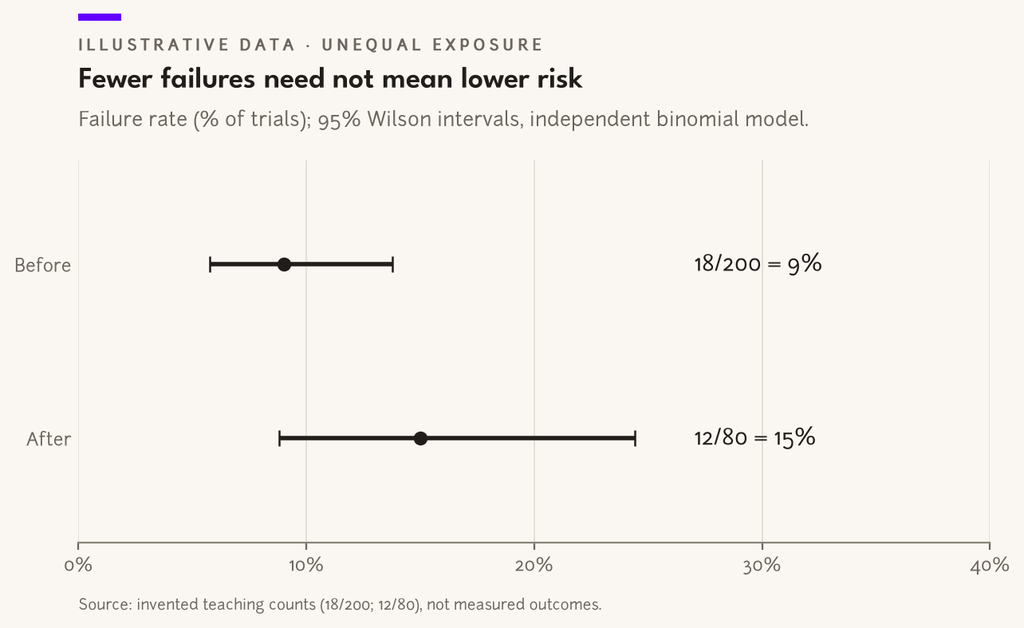

(b)

Figure 1

```
| Period | Failures / trials | Rate | 95% Wilson interval |
|---|---:|---:|---:|
| Before | 18 / 200 | 9.0% | 5.8%–13.8% |
| After | 12 / 80 | 15.0% | 8.8%–24.4% |
```

**Review outcome.** Counts decreased by one third, while the observed rate increased by 6 percentage points. The two rate intervals do not test the difference. A decision about harm would need a pre-specified practical threshold, a suitable difference estimate, and attention to changes in case mix, exposure, and measurement. Equal ink and direct labels avoid suggesting one period deserves trust or blame; the table provides a non-visual route. The release checklist still requires inspection of the final export and reader comprehension.

# 2 M0 — Environment & the mental model

**Principle.** Explicit object handles make visual decisions reproducible. One source of layout bugs is *fighting the pyplot state machine* — the `plt.plot`, `plt.title`, `plt.xlabel` style, where “the current axes” is invisible global state you can only nudge, never hold. The cure is one line, and it reorganizes everything that follows.

## 2.1 The pyplot state machine vs. holding handles

The `plt.*` interface always draws on a hidden “current figure / current axes”. That is convenient for a one-off in a REPL and a trap for anything real: you cannot point at the second of two axes, you cannot pass *the* line to a helper, and every tweak is a fresh global command hoping the right object is current.

Hold the handles instead:

```python
fig, ax = plt.subplots()   # fig = the whole canvas;  ax = one plotting region
ax.plot(x, y)              # operate on the OBJECT, not on hidden global state
```

`fig` and `ax` are real objects. You can store them, pass them around, ask them questions (`ax.get_xlim()`), and hand `ax` to a styling function. Everything below is a consequence of this.

**ImportantExtract — the OO-API rule**

Always `fig, ax = plt.subplots(constrained_layout=True)`. After that, **no `plt.*` plotting calls** — operate on `ax`/`fig`. The only `plt.*` you keep are `plt.subplots` itself and `plt.style.*` (both wrapped by `house_style.theme`).

## 2.2 The look we’re escaping

Here is a perfectly ordinary chart drawn the perfectly ordinary way. Read it, then notice everything you have to *squint past*: the box of four spines, a default-blue line that means nothing, ticks at 0/2/4/…, a y-axis in bare thousands, and a title that just names the variable.

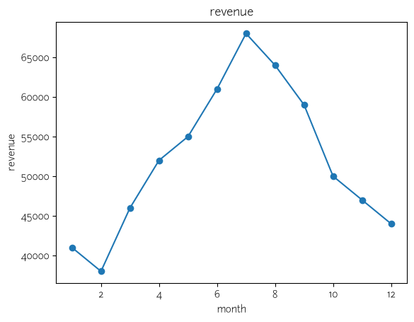

Matplotlib’s raw defaults — competent, anonymous, and a little hard to read.

```python
months = np.arange(1, 13)
revenue = np.array([41, 38, 46, 52, 55, 61, 68, 64, 59, 50, 47, 44]) * 1000

# A counterexample: defaults ON PURPOSE (note: no house_style.theme, raw style context).
with plt.style.context("default"):
    fig, ax = plt.subplots()
    ax.plot(months, revenue, marker="o")
    ax.set_title("revenue")
    ax.set_xlabel("month")
    ax.set_ylabel("revenue")
```

## 2.3 The same data, rebuilt on the OO API

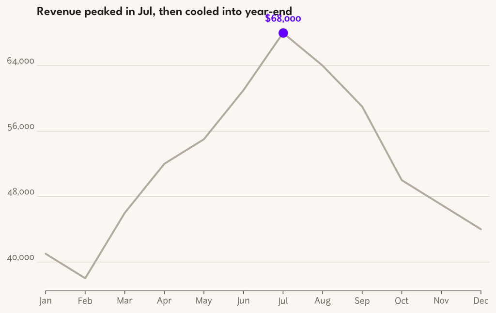

Same data on the OO API: grey for context, one accent for the point, a title that says something.

```python
month_names = ["Jan", "Feb", "Mar", "Apr", "May", "Jun",
               "Jul", "Aug", "Sep", "Oct", "Nov", "Dec"]
peak_month_index = int(revenue.argmax())

fig, ax = plt.subplots(constrained_layout=True)
ax.plot(months, revenue, color=GREY, lw=2)  # the monthly series = context, in grey
ax.plot(months[peak_month_index], revenue[peak_month_index], "o", color=ACCENT, ms=9, zorder=5)

title(ax, f"Revenue peaked in {month_names[peak_month_index]}, then cooled into year-end")
house_style.finish(ax)  # tick budget, hairline grid, bounded bottom spine
house_style.units(ax, "y", "count")  # 68000 -> 68,000

ax.set_xticks(months)
ax.set_xticklabels(month_names)
ax.margins(x=0.02)

# Direct label on the accent point — in DATA coordinates, offset a few points up.
# (Keeping the handle both suppresses Jupyter's repr echo and proves the point:
#  the annotation is just another Artist you can hold and re-`.set_*()` later.)
peak_label = ax.annotate(
    f"${revenue[peak_month_index]:,.0f}",
    xy=(months[peak_month_index], revenue[peak_month_index]),
    xytext=(0, 12),
    textcoords="offset points",
    ha="center",
    color=ACCENT,
    fontweight="bold",
)
```

The data are unchanged. The styling changes attention, not evidential strength: verify that the highlighted point deserves that attention.

## 2.4 Figure → Axes → Artist: the hierarchy

Three nested ideas explain the whole library:

- **Figure** — the canvas. It owns the size, the DPI, and one or more Axes. Saving is a Figure operation (`fig.savefig`).
- **Axes** — one plotting region: its own data limits, ticks, labels, and spines. “Subplot” = one Axes.
- **Artist** — *everything drawn is one*. Every line, marker, tick, label, spine, and patch is an `Artist` you can grab and `.set_*()`. There is no styling you cannot reach this way.

The figure below labels its own parts — and does the labelling in **axes-fraction** coordinates, which sets up the next idea.

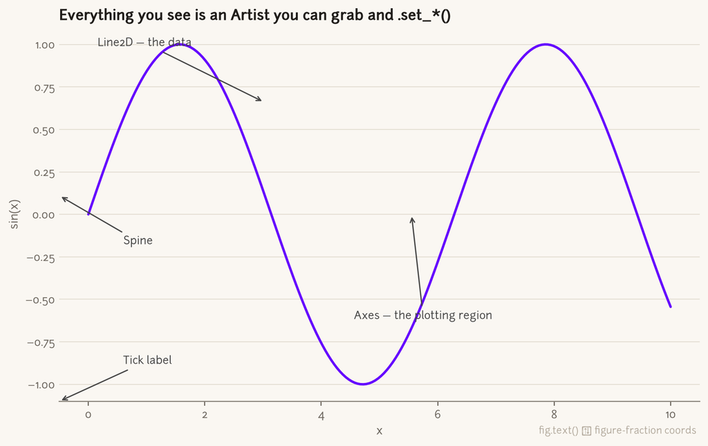

Every visible thing is an Artist. Callouts are placed in axes-fraction coordinates.

```python
x_values = np.linspace(0, 10, 200)

fig, ax = plt.subplots(figsize=(8, 5), constrained_layout=True)
(sine_line,) = ax.plot(x_values, np.sin(x_values), color=ACCENT, lw=2)  # a Line2D Artist we keep a handle to
ax.set_title("Everything you see is an Artist you can grab and .set_*()", loc="left")
ax.set_xlabel("x")
ax.set_ylabel("sin(x)")


def callout(text, point, label_at):
    ax.annotate(
        text,
        xy=point,
        xycoords="axes fraction",
        xytext=label_at,
        textcoords="axes fraction",
        fontsize=9,
        color="#444444",
        ha="left",
        arrowprops=dict(arrowstyle="->", color="#444444", lw=1),
    )


callout("Line2D — the data", point=(0.32, 0.80), label_at=(0.06, 0.95))
callout("Axes — the plotting region", point=(0.55, 0.50), label_at=(0.46, 0.22))
callout("Spine", point=(0.00, 0.55), label_at=(0.10, 0.42))
callout("Tick label", point=(0.00, 0.00), label_at=(0.10, 0.10))

# fig.text places relative to the whole CANVAS (figure fraction), not this Axes.
source_note = fig.text(
    0.99, 0.01, "fig.text() → figure-fraction coords", ha="right", va="bottom", fontsize=8, color=GREY
)
```

## 2.5 Coordinate systems & transforms

When you place text or an arrow, you choose *which coordinate system the numbers mean*. matplotlib gives you four, and switching between them is the difference between “annotation glued to a data point” and “annotation glued to a corner of the panel”:

| System | What `(0.5, 0.5)` means | Reach it with |
| --- | --- | --- |
| **data** | the middle of the *data range* (moves if the data changes) | default `xy=` |
| **axes fraction** | the centre of *this Axes*, always | `xycoords="axes fraction"` / `transform=ax.transAxes` |
| **figure fraction** | the centre of the *whole canvas* | `fig.text` / `transform=fig.transFigure` |
| **display** | a pixel on screen | rarely by hand |

The proof that axes-fraction is data-independent: the same `(0.5, 0.5)` lands in the same visual spot in both panels below, even though their y-ranges differ by 1000×.

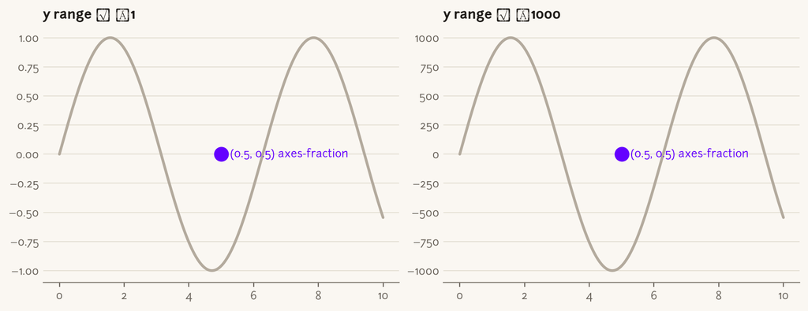

Same axes-fraction point (0.5, 0.5) in both panels — identical position despite a 1000x data-range gap.

```python
fig, axes = plt.subplots(1, 2, figsize=(9, 3.4), constrained_layout=True)

for ax, y_scale in zip(axes, [1, 1000]):
    ax.plot(x_values, y_scale * np.sin(x_values), color=GREY)
    ax.set_title(f"y range ≈ ±{y_scale}", loc="left", fontsize=11)
    # transform=ax.transAxes makes these numbers mean "fraction of THIS axes".
    ax.plot(0.5, 0.5, "o", color=ACCENT, ms=11, transform=ax.transAxes)
    ax.text(
        0.5, 0.5, "   (0.5, 0.5) axes-fraction", transform=ax.transAxes,
        va="center", color=ACCENT, fontsize=9,
    )
```

## 2.6 Before & after — the same series, raw vs. house

Everything in M0 in one comparison, on real data: the classic airline-passengers series (1949–1960), drawn first with matplotlib’s untouched defaults, then rebuilt on the OO API under `house_style.theme`. The defaults and the house theme are *different rcParams*, so this has to be **two figures** — you can’t put a truly raw axes beside a themed one in a single canvas, because the theme is global.

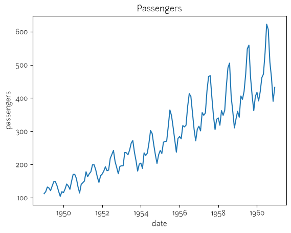

Before — matplotlib’s untouched defaults: boxed in, primary blue, a title that just renames the y-axis.

```python
flights = load("flights")
month_index = np.array([list(MONTHS).index(month_name) for month_name in flights["month"]])  # name → 0..11
decimal_year = flights["year"] + month_index / 12
chronological = np.argsort(decimal_year)
decimal_year, passengers = decimal_year[chronological], flights["passengers"][chronological]

with plt.style.context("default"):  # the only honest way to show raw defaults post-theme
    fig, ax = plt.subplots()
    ax.plot(decimal_year, passengers)
    ax.set_title("Passengers")
    ax.set_xlabel("date")
    y_axis_label = ax.set_ylabel("passengers")
```

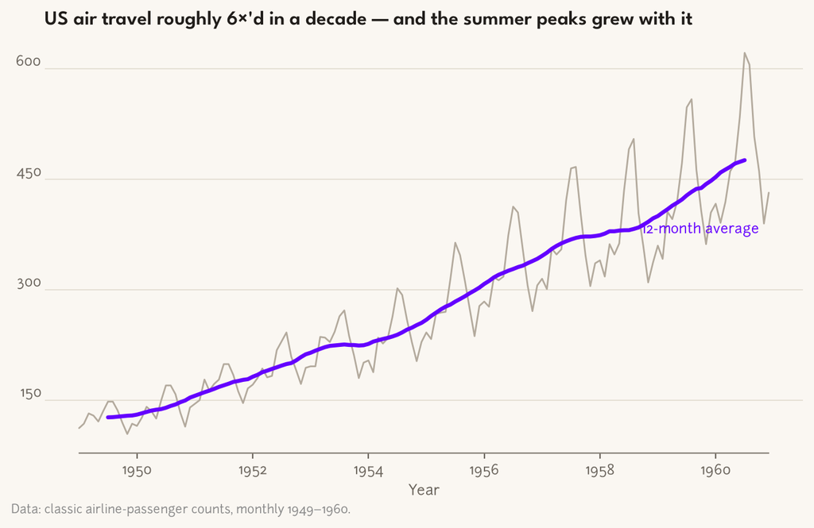

After — the OO API under house_style.theme: grey for context, the accent on the trend, a takeaway title, a finished axes.

```python
fig, ax = plt.subplots(constrained_layout=True)
ax.plot(decimal_year, passengers, color=GREY, lw=1.1)  # the monthly series = context

twelve_month_trend = rolling_mean(passengers, 12)  # the point: the 12-month trend
ax.plot(decimal_year, twelve_month_trend, color=ACCENT, lw=2.6)

growth_multiple = passengers.max() / passengers.min()  # compute the multiple, don't guess it
house_style.finish(ax)
title(ax, f"US air travel roughly {growth_multiple:.0f}×'d in a decade — and the summer peaks grew with it")
ax.set_xlabel("Year")
trend_label = ax.annotate(
    "12-month average",
    (decimal_year[-30], twelve_month_trend[-30]),
    color=ACCENT,
    fontsize=9,
    xytext=(8, -2),
    textcoords="offset points",
)
source = fig.text(
    0.0, -0.02, "Data: classic airline-passenger counts, monthly 1949–1960.", fontsize=8, color="#8a8a8a"
)
```

The data didn’t change — the *decisions* did: trimmed spines, grey for context with the accent on the trend, and a title that says what happened instead of renaming the axis.

**ImportantExtract — M0 rules**

**Acceptance check:** the plotted arrays and units are unchanged by styling; no emphasis implies an unsupported finding.

1. **Hold handles.** `fig, ax = plt.subplots(constrained_layout=True)`; never `plt.*` plotting afterward.
2. **Everything is an Artist** — to change anything, grab it and `.set_*()`.
3. **Pick the coordinate system deliberately** — data for things tied to values, axes-fraction for things tied to the panel (titles, source notes, callouts that should not move with the data).

# 3 M1 — Chart choice: ask before you plot

M0 gave you the tools to draw anything. M1 is the discipline of drawing the **right** thing. The most expensive mistake in a chart is made *before any code runs* — choosing a form that cannot answer the question. So the rule of this module is a sentence you say out loud first:

> **“`<chart>` because `<shape>` + `<task>`.”** — stated before you type `plt.subplots`.

The full framework — the pre-flight checklist, a *(data shape × task) → chart* lookup, a chart catalog, and the anti-patterns — lives in [`VISUALIZATION_GUIDE.md`](https://github.com/temataro/better-graphs/blob/gpt-6-astra/VISUALIZATION_GUIDE.md). Here we *earn* three of its hardest lessons by doing each the wrong way first, on the project’s real datasets.

**NoteThe pre-flight checklist (the condensed version)**

1. **Evidence and question** — inspect provenance, units, missingness and scope before deciding what the title can claim.
2. **Audience & medium — pick the register** — slide/poster → `glance`; report/README → `read`; appendix/datasheet → `study`.
3. **Data shape** — how many variables, each one’s *type* (quantitative / categorical / temporal / geographic), how many rows & categories.
4. **Task — the verb** — comparison · ranking · distribution · relationship · part-to-whole · evolution · deviation · flow · spatial.
5. **→ Chart** — read *(shape × task)* off the table in `VISUALIZATION_GUIDE.md`, and say the sentence.

```python
gapminder = load("gapminder")  # dict of numpy arrays, one per column
datasaurus = load("datasaurus")
```

## 3.1 Lesson 1 — distrust the summary (why we plot at all)

Before you can choose *how* to show data, you have to **look** at it — because the numbers you’d otherwise choose from can be identical for wildly different data. The Datasaurus Dozen is engineered to prove exactly that: thirteen datasets with the same mean and standard deviation (to two decimals) and a near-identical, near-zero correlation — yet wildly different shapes.

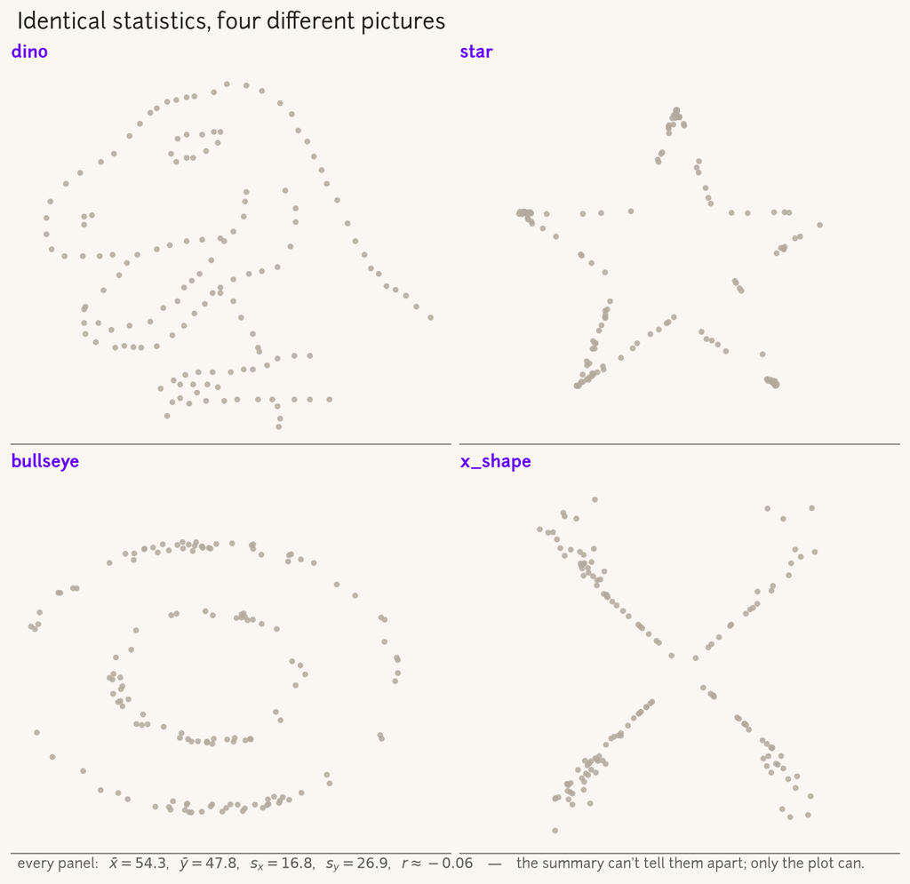

Four engineered Datasaurus datasets share summary statistics; scatterplots reveal their different shapes.

```python
featured_shapes = ["dino", "star", "bullseye", "x_shape"]

# Compute the shared statistics from the data — never transcribe remembered constants.
is_first_shape = datasaurus["dataset"] == featured_shapes[0]
mean_x, mean_y = datasaurus["x"][is_first_shape].mean(), datasaurus["y"][is_first_shape].mean()
std_x, std_y = std(datasaurus["x"][is_first_shape]), std(datasaurus["y"][is_first_shape])
correlation = corr(datasaurus["x"][is_first_shape], datasaurus["y"][is_first_shape])

fig, axes = plt.subplots(2, 2, figsize=(8, 7.6), sharex=True, sharey=True, constrained_layout=True)
for ax, shape_name in zip(axes.flat, featured_shapes):
    in_shape = datasaurus["dataset"] == shape_name
    ax.scatter(
        datasaurus["x"][in_shape], datasaurus["y"][in_shape],
        s=14, color=GREY, alpha=0.85, edgecolor="none",
    )
    ax.set_title(shape_name, loc="left", fontsize=11, color=ACCENT)
    ax.set_xticks([])
    ax.set_yticks([])

fig.suptitle("Identical statistics, four different pictures", x=0.012, ha="left", fontsize=14, weight="medium")
# mathtext keeps the symbols crisp and font-independent (League Spartan has no subscript glyphs).
shared_stats = (
    rf"every panel:   $\bar{{x}}={mean_x:.1f}$,   $\bar{{y}}={mean_y:.1f}$,   "
    rf"$s_x={std_x:.1f}$,   $s_y={std_y:.1f}$,   $r\approx{correlation:+.2f}$"
)
caption = fig.text(
    0.012, -0.012,
    shared_stats + "    —    the summary can't tell them apart; only the plot can.",
    fontsize=9, color="#5a5a5a",
)
```

If you’d picked a chart — or drawn a conclusion — from those five numbers, you’d have been wrong four different ways. **Plot first; the shape of the data decides the chart.**

## 3.2 Lesson 2 — two time points want a dumbbell, not grouped bars

*Task:* the **change** across categories between two times. *Shape:* one categorical (country) + two quantitative (life expectancy in 1952 and 2007). Grouped bars encode the two *levels* faithfully — but the reader came for the *change*, and bars make them compute it by eye. A **dumbbell** encodes the change directly: it **is** the segment between the two dots.

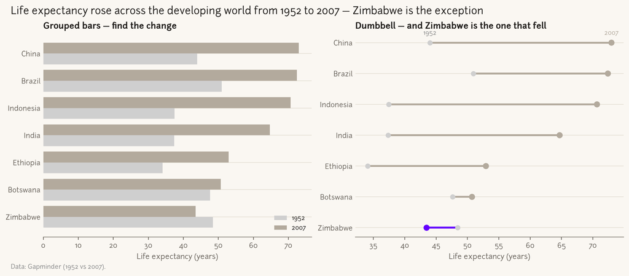

Same numbers, two encodings. Grouped bars make you subtract; the dumbbell shows the change — and the exception.

```python
countries = ["China", "Indonesia", "Brazil", "India", "Botswana", "Ethiopia", "Zimbabwe"]
is_endpoint_year = np.isin(gapminder["country"], countries) & np.isin(gapminder["year"], [1952, 2007])
country, _, life_exp_matrix = pivot(
    gapminder["country"][is_endpoint_year],
    gapminder["year"][is_endpoint_year],
    gapminder["lifeExp"][is_endpoint_year],
    rows=countries,
    cols=[1952, 2007],
)
order_by_2007 = np.argsort(life_exp_matrix[:, 1])  # sort by the 2007 value
country, life_exp_matrix = country[order_by_2007], life_exp_matrix[order_by_2007]
life_exp_1952, life_exp_2007 = life_exp_matrix[:, 0], life_exp_matrix[:, 1]
row = np.arange(len(country))
rose_mask = life_exp_2007 >= life_exp_1952  # True except where it fell
marker_color = np.where(rose_mask, GREY, ACCENT)  # one accent: the country that fell

fig, (grouped_ax, dumbbell_ax) = plt.subplots(1, 2, figsize=(11, 4.6), constrained_layout=True)

# WRONG — grouped bars: tall and honest, but "how much did it CHANGE?" is buried.
bar_height = 0.4
grouped_ax.barh(row - bar_height / 2, life_exp_1952, height=bar_height, color="#cfcfcf", label="1952")
grouped_ax.barh(row + bar_height / 2, life_exp_2007, height=bar_height, color=GREY, label="2007")
grouped_ax.set_yticks(row)
grouped_ax.set_yticklabels(country)
grouped_ax.set_xlabel("Life expectancy (years)")
grouped_ax.set_title("Grouped bars — find the change", loc="left", fontsize=11)
grouped_ax.legend(loc="lower right", frameon=False, fontsize=8)

# RIGHT — dumbbell: the connecting segment IS the change; colour flags the one exception.
dumbbell_ax.hlines(row, life_exp_1952, life_exp_2007, color=marker_color, lw=2.4, zorder=1)
dumbbell_ax.scatter(life_exp_1952, row, color="#cfcfcf", s=44, zorder=2)
dumbbell_ax.scatter(life_exp_2007, row, color=marker_color, s=60, zorder=3)
dumbbell_ax.set_yticks(row)
dumbbell_ax.set_yticklabels(country)
dumbbell_ax.set_xlabel("Life expectancy (years)")
dumbbell_ax.set_title("Dumbbell — and Zimbabwe is the one that fell", loc="left", fontsize=11)
top_row = len(country) - 1
label_1952 = dumbbell_ax.annotate(
    "1952", (life_exp_1952[top_row], top_row), textcoords="offset points",
    xytext=(0, 10), ha="center", fontsize=8, color="#8a8a8a",
)
label_2007 = dumbbell_ax.annotate(
    "2007", (life_exp_2007[top_row], top_row), textcoords="offset points",
    xytext=(0, 10), ha="center", fontsize=8, color=GREY,
)

fig.suptitle(
    "Life expectancy rose across the developing world from 1952 to 2007 — Zimbabwe is the exception",
    x=0.012, ha="left", fontsize=13, weight="medium",
)
source = fig.text(0.012, -0.02, "Data: Gapminder (1952 vs 2007).", fontsize=8, color="#8a8a8a")
```

Same numbers in both panels. The bars are honest but mute; the dumbbell says *“almost everyone rose — and here is the one who didn’t”* before you’ve read a single label.

## 3.3 Lesson 3 — ranking shares favours bars over angles

*Task:* part-to-whole **and** ranking. A pie asks the reader to compare angles and chase a legend; past about five slices it fails at the very thing ranking needs. A **sorted bar** makes order and magnitude immediate — so the bar is a better starting point for this nine-category ranking. A few labelled slices can still serve a rough part-to-whole task.

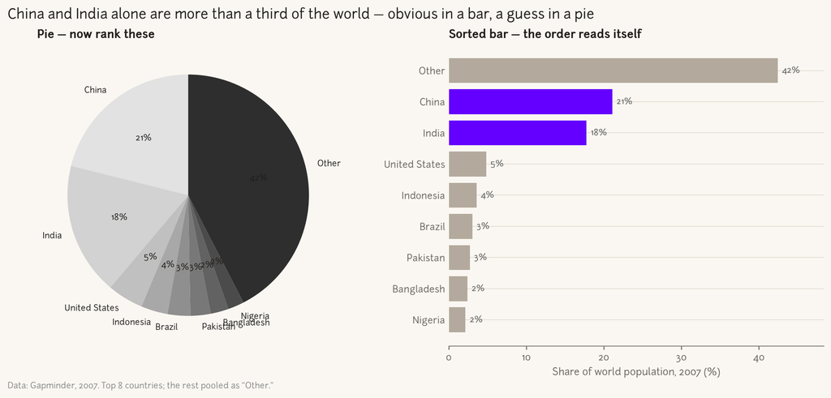

World population 2007 by country. The pie hides the ranking the sorted bar makes obvious.

```python
# In 2007 each country appears once, so its row IS its population — sort, take the top 8, pool the rest.
is_2007 = gapminder["year"] == 2007
country, population = gapminder["country"][is_2007], gapminder["pop"][is_2007]
by_population_desc = np.argsort(population)[::-1]
country, population = country[by_population_desc], population[by_population_desc]
segment_label = np.append(country[:8], "Other")
segment_population = np.append(population[:8], population[8:].sum())
segment_share = 100 * segment_population / segment_population.sum()

fig, (pie_ax, bar_ax) = plt.subplots(1, 2, figsize=(11, 5), constrained_layout=True)

# WRONG — pie: nine wedges, a legend, and you still can't rank them by eye.
grey_ramp = plt.cm.Greys(np.linspace(0.2, 0.85, len(segment_population)))
pie_wedges, pie_labels, pie_pcts = pie_ax.pie(
    segment_population, labels=segment_label, autopct="%1.0f%%", colors=grey_ramp,
    startangle=90, textprops={"fontsize": 8},
)
pie_ax.set_title("Pie — now rank these", loc="left", fontsize=11)

# RIGHT — sorted bar of shares: ranking and magnitude in one read; accent the two giants.
by_share_asc = np.argsort(segment_share)  # ascending → longest bar on top
bar_label, bar_share = segment_label[by_share_asc], segment_share[by_share_asc]
row = np.arange(len(bar_share))
bar_color = [ACCENT if name in ("China", "India") else GREY for name in bar_label]
bar_ax.barh(row, bar_share, color=bar_color)
bar_ax.set_yticks(row)
bar_ax.set_yticklabels(bar_label)
bar_ax.set_xlabel("Share of world population, 2007 (%)")
bar_ax.set_title("Sorted bar — the order reads itself", loc="left", fontsize=11)
bar_ax.margins(x=0.14)
for row_y, share_value in zip(row, bar_share):
    bar_ax.annotate(
        f"{share_value:.0f}%", (share_value, row_y), xytext=(4, 0), textcoords="offset points",
        va="center", fontsize=8, color="#5a5a5a",
    )

fig.suptitle(
    "China and India alone are more than a third of the world — obvious in a bar, a guess in a pie",
    x=0.012, ha="left", fontsize=13, weight="medium",
)
source = fig.text(
    0.012, -0.02, "Data: Gapminder, 2007. Top 8 countries; the rest pooled as “Other.”",
    fontsize=8, color="#8a8a8a",
)
```

Both panels show the same nine numbers. The bar makes close ranks easier to compare — and the accent puts the two-country dominance where the eye lands first.

## 3.4 Before & after — a relationship needs a scatter, not a bar of means

One more chart-choice, on the Palmer penguins. The question is *how do flipper length and body mass relate, and does it differ by species?* A bar of mean mass is a true fact that answers a different question; the scatter answers the one we asked — and the cluster structure falls out for free.

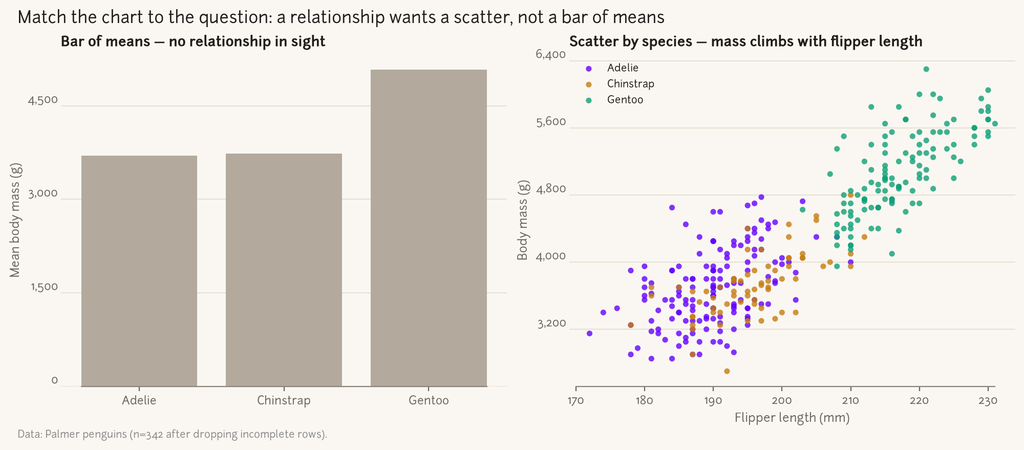

Same question — how do flipper length and mass relate? A bar of means can’t answer it; a scatter can.

```python
penguins = load("penguins")
penguins = select(penguins, finite(penguins["flipper_length_mm"], penguins["body_mass_g"]))  # ≈ dropna
species = ["Adelie", "Chinstrap", "Gentoo"]
species_color = {"Adelie": ACCENT, "Chinstrap": house_style.OCHRE, "Gentoo": house_style.EMERALD}  # 3 series → SERIES[:3]

fig, (bar_ax, scatter_ax) = plt.subplots(1, 2, figsize=(11, 4.6), constrained_layout=True)

# BEFORE — bar of mean mass: a true fact, but it answers the wrong question.
_, mean_mass = group(penguins["species"], penguins["body_mass_g"], np.nanmean, order=species)
bar_ax.bar(species, mean_mass, color=GREY)
bar_ax.set_ylabel("Mean body mass (g)")
bar_ax.set_title("Bar of means — no relationship in sight", loc="left", fontsize=11)
house_style.finish(bar_ax)
house_style.units(bar_ax, "y", "count")

# AFTER — scatter by species: the relationship and the clusters both appear.
for species_name in species:
    in_species = penguins["species"] == species_name
    scatter_ax.scatter(
        penguins["flipper_length_mm"][in_species], penguins["body_mass_g"][in_species],
        s=20, color=species_color[species_name], alpha=0.8, edgecolor="none", label=species_name,
    )
scatter_ax.set_xlabel("Flipper length (mm)")
scatter_ax.set_ylabel("Body mass (g)")
scatter_ax.set_title("Scatter by species — mass climbs with flipper length", loc="left", fontsize=11)
house_style.finish(scatter_ax)
house_style.units(scatter_ax, "y", "count")
scatter_ax.legend(frameon=False, fontsize=8, loc="upper left")

fig.suptitle(
    "Match the chart to the question: a relationship wants a scatter, not a bar of means",
    x=0.012, ha="left", fontsize=13, weight="medium",
)
source = fig.text(
    0.012, -0.02, f"Data: Palmer penguins (n={len(penguins['species'])} after dropping incomplete rows).",
    fontsize=8, color="#8a8a8a",
)
```

The bar isn’t *wrong* — it’s answering a question nobody asked. Choosing the chart is choosing which question the reader gets to answer.

**ImportantExtract — M1 rules**

**Acceptance check:** a reader can perform the intended comparison; check excluded/unpaired observations and whether a table would be more precise.

1. **Ask before you plot.** Say *“`<chart>` because `<shape>` + `<task>`”* before `plt.subplots`. The full checklist, the *(shape × task) → chart* lookup, and the catalog live in `VISUALIZATION_GUIDE.md`.
2. **Match the encoding to the task’s *verb*, not the data’s columns** — change → dumbbell/slope, part-to-whole → sorted bar, relationship → scatter.
3. **Look before you choose.** Summary statistics can’t pick a chart (or a conclusion); only the data’s shape can — so plot it first.

# 4 M2 — Layout & composition: the figure is the master coordinate

A chart’s real coordinate system isn’t the data — it’s the **figure**: its size in inches times its dpi. Every point, line width, and margin is measured against that. A 10-pt label is physically 10 pt whether the figure is 4 inches wide or 12, so it reads *large* on a small figure and *lost* on a big one. Composition therefore starts with one decision — **how big is this figure, and where will it live** — and everything else follows. `constrained_layout=True` then keeps panels, ticks, and titles from colliding without hand-tuning.

## 4.1 A dashboard with `subplot_mosaic`

`subplot_mosaic` lays out named panels from an ASCII sketch — a main view plus context panels — and the real craft is sharing **one colour encoding** across them so the eye carries meaning from panel to panel.

[figure not shown]

subplot_mosaic: a main view plus two context panels, with a single continent colour key shared across them.

```python
gapminder_2007 = select(gapminder, gapminder["year"] == 2007)
continent_color = {
    "Africa": house_style.VIOLET, "Americas": house_style.OCHRE, "Asia": house_style.EMERALD,
    "Europe": house_style.WINE, "Oceania": house_style.NAVY,
}

fig, mosaic = plt.subplot_mosaic(
    "AB\nAC", figsize=(10, 5.4), constrained_layout=True, gridspec_kw={"width_ratios": [2, 1]}
)

# A — the main view: wealth vs health, bubble area ∝ population, colour = continent.
scatter_ax = mosaic["A"]
for continent_name, color in continent_color.items():
    in_continent = gapminder_2007["continent"] == continent_name
    scatter_ax.scatter(
        gapminder_2007["gdpPercap"][in_continent],
        gapminder_2007["lifeExp"][in_continent],
        s=np.sqrt(gapminder_2007["pop"][in_continent]) / 200,
        color=color, alpha=0.75, edgecolor="white", linewidth=0.3, label=continent_name,
    )
scatter_ax.set_xscale("log")
scatter_ax.set_xlabel("GDP per capita (log scale, $)")
scatter_ax.set_ylabel("Life expectancy (years)")
scatter_ax.set_title(r"Wealth vs. health, 2007 — bubble area $\propto$ population", loc="left", fontsize=11)
house_style.finish(scatter_ax)
scatter_ax.legend(frameon=False, fontsize=7, loc="lower right", ncol=2)

# B — context: the distribution of the y variable.
distribution_ax = mosaic["B"]
distribution_ax.hist(gapminder_2007["lifeExp"], bins=12, color=GREY)
distribution_ax.set_title("Distribution", loc="left", fontsize=10)
house_style.finish(distribution_ax)

# C — context: median by continent, the SAME colour key as the scatter.
median_ax = mosaic["C"]
continent, median_life_exp = group(gapminder_2007["continent"], gapminder_2007["lifeExp"], np.nanmedian)
order_by_median = np.argsort(median_life_exp)
continent, median_life_exp = continent[order_by_median], median_life_exp[order_by_median]
median_color = [continent_color[name] for name in continent]
median_ax.barh(range(len(median_life_exp)), median_life_exp, color=median_color)
median_ax.set_yticks(range(len(median_life_exp)))
median_ax.set_yticklabels(continent, fontsize=8)
median_ax.set_title("Median, by continent", loc="left", fontsize=10)
house_style.finish(median_ax)

source = fig.text(0.0, -0.02, "Data: Gapminder, 2007.", fontsize=8, color="#8a8a8a")
```

## 4.2 Magnify without losing the overview

An **inset** keeps the full trace *and* a zoomed detail in one figure — pick the zoom window from the data, not by eye.

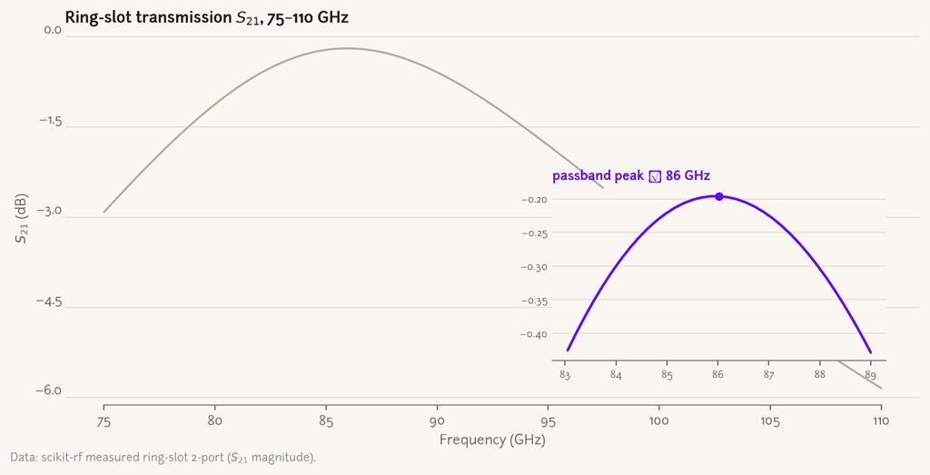

An inset magnifies the passband peak of a measured S21 trace while the overview stays put.

```python
ring_slot = load("rf_ring_slot")
frequency_ghz = ring_slot["freq_ghz"]
s21_db = 20 * np.log10(np.abs(ring_slot["s21"]))  # magnitude in dB, straight from the complex S-parameter

fig, ax = plt.subplots(figsize=(9, 4.4), constrained_layout=True)
ax.plot(frequency_ghz, s21_db, color=GREY, lw=1.4)

peak_index = np.argmax(s21_db)  # zoom on the passband peak — computed, not eyeballed
peak_frequency = frequency_ghz[peak_index]
passband = (frequency_ghz >= peak_frequency - 3) & (frequency_ghz <= peak_frequency + 3)

inset_ax = ax.inset_axes([0.57, 0.12, 0.39, 0.46])
inset_ax.plot(frequency_ghz[passband], s21_db[passband], color=ACCENT, lw=1.8)
inset_ax.scatter([peak_frequency], [s21_db[peak_index]], color=ACCENT, zorder=3)
inset_ax.set_title(f"passband peak ≈ {peak_frequency:.0f} GHz", loc="left", fontsize=9, color=ACCENT)
inset_ax.tick_params(labelsize=7)
ax.indicate_inset_zoom(inset_ax, edgecolor="#999999")

ax.set_xlabel("Frequency (GHz)")
ax.set_ylabel(r"$S_{21}$ (dB)")
ax.set_title(r"Ring-slot transmission $S_{21}$, 75–110 GHz", loc="left", fontsize=11)
house_style.finish(ax)
source = fig.text(
    0.0, -0.02, r"Data: scikit-rf measured ring-slot 2-port ($S_{21}$ magnitude).", fontsize=8, color="#8a8a8a"
)
```

## 4.3 Before & after — spaghetti vs. small multiples

The most common layout failure is forcing many series into one axes. Same data, two layouts:

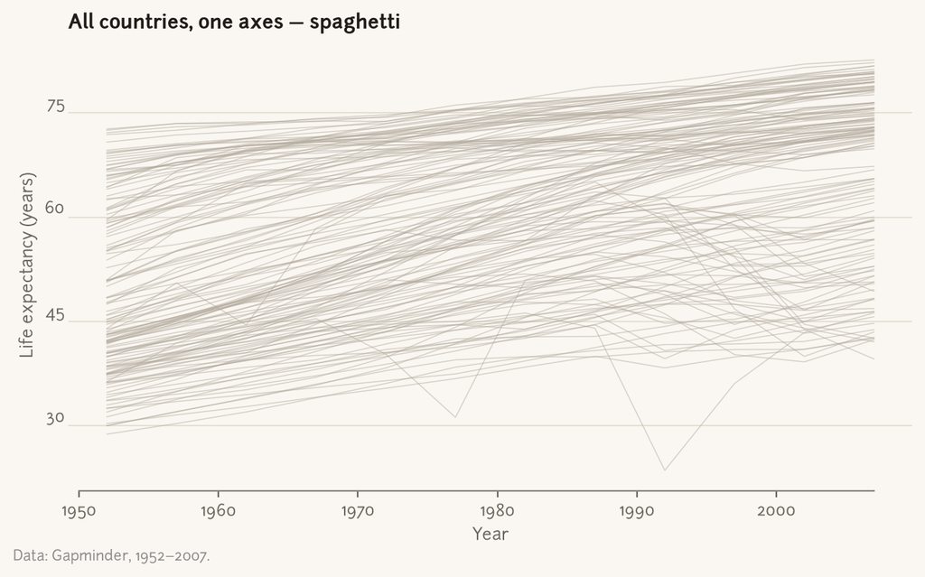

Before — every country’s trajectory in one axes. All the data is here; none of it is readable.

```python
fig, ax = plt.subplots(figsize=(7, 4.2), constrained_layout=True)
for country_name in np.unique(gapminder["country"]):
    in_country = gapminder["country"] == country_name
    by_year = np.argsort(gapminder["year"][in_country])
    ax.plot(
        gapminder["year"][in_country][by_year],
        gapminder["lifeExp"][in_country][by_year],
        color=GREY, lw=0.6, alpha=0.5,
    )
ax.set_xlabel("Year")
ax.set_ylabel("Life expectancy (years)")
ax.set_title("All countries, one axes — spaghetti", loc="left", fontsize=11)
house_style.finish(ax)
note = fig.text(0.0, -0.02, "Data: Gapminder, 1952–2007.", fontsize=8, color="#8a8a8a")
```

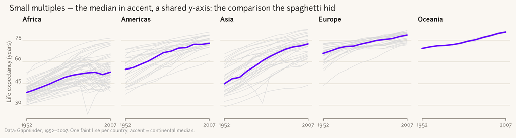

After — one panel per continent, the continental median in accent, a shared y-axis. Every region is legible.

```python
continents = ["Africa", "Americas", "Asia", "Europe", "Oceania"]
fig, axes = plt.subplots(1, 5, figsize=(12, 3.0), sharey=True, constrained_layout=True)
for ax, continent_name in zip(axes, continents):
    in_continent = gapminder["continent"] == continent_name
    for country_name in np.unique(gapminder["country"][in_continent]):
        in_country = in_continent & (gapminder["country"] == country_name)
        by_year = np.argsort(gapminder["year"][in_country])
        ax.plot(
            gapminder["year"][in_country][by_year],
            gapminder["lifeExp"][in_country][by_year],
            color="#dadada", lw=0.7,
        )
    year, median_life_exp = group(
        gapminder["year"][in_continent], gapminder["lifeExp"][in_continent], np.nanmedian
    )
    ax.plot(year, median_life_exp, color=ACCENT, lw=2.4)
    ax.set_title(continent_name, loc="left", fontsize=11)
    ax.set_xticks([1952, 2007])
    house_style.finish(ax)
axes[0].set_ylabel("Life expectancy (years)")
fig.suptitle(
    "Small multiples — the median in accent, a shared y-axis: the comparison the spaghetti hid",
    x=0.01, ha="left", fontsize=13, weight="medium",
)
source = fig.text(
    0.0, -0.02,
    "Data: Gapminder, 1952–2007. One faint line per country; accent = continental median.",
    fontsize=8, color="#8a8a8a",
)
```

**ImportantExtract — M2 rules**

**Acceptance check:** inspect the final column/slide size, not only the notebook. Shared scales enable magnitude comparison; label free scales if inspecting shape instead.

1. **The figure is the master coordinate.** Choose figure size (inches) × dpi *first* — points are physical, so a 10-pt label is larger on a small figure — then let `constrained_layout=True` manage spacing.
2. **Compose, don’t cram.** `subplot_mosaic` lays out a main view plus context panels; share one colour encoding across them so meaning carries between panels.
3. **Many overlapping series → consider small multiples.** Use shared axes for magnitude comparison; preserve individual trajectories when variation is the task.
4. **Zoom with an inset** (`ax.inset_axes` + `ax.indicate_inset_zoom`) to keep overview and detail together.

# 5 M3 — Typography: the page carries the legend

Type provides orientation and hierarchy. In the example below, a supported finding leads and series names are colour-keyed into the dek with `page(dek_highlights=...)`. This can reduce lookup, but coloured words alone do not guarantee accessible identification. Use end labels, distinct line styles or a legend when needed. A descriptive title is valid when the task is exploration or lookup.

## 5.1 The legend, dissolved into the dek

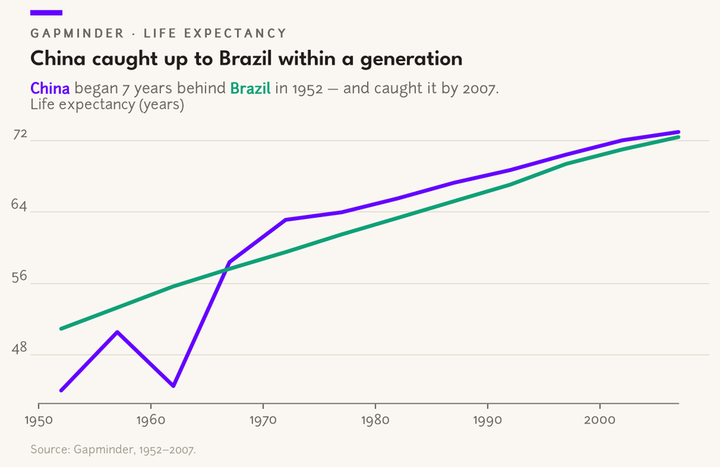

Each country’s name is coloured to its line in the dek — no legend box, no round-trip for the eye.

```python
series_color = {"China": ACCENT, "Brazil": house_style.EMERALD}


def life_exp_in(country, year):
    return gapminder["lifeExp"][(gapminder["country"] == country) & (gapminder["year"] == year)][0]


years_behind_in_1952 = life_exp_in("Brazil", 1952) - life_exp_in("China", 1952)  # compute it, don't guess

house_style.theme("read")
fig, ax = house_style.page(
    kicker="Gapminder · life expectancy",
    title="China caught up to Brazil within a generation",
    dek=f"<China> began {years_behind_in_1952:.0f} years behind <Brazil> in 1952 — and caught it by 2007.",
    dek_highlights=[
        {"color": series_color["China"], "weight": "bold"},
        {"color": series_color["Brazil"], "weight": "bold"},
    ],
    source="Source: Gapminder, 1952–2007.",
)
for country_name in series_color:
    in_country = gapminder["country"] == country_name
    by_year = np.argsort(gapminder["year"][in_country])
    ax.plot(
        gapminder["year"][in_country][by_year],
        gapminder["lifeExp"][in_country][by_year],
        color=series_color[country_name], lw=2.6,
    )
house_style.finish(ax)
house_style.ylabel_above(ax, "Life expectancy (years)")
```

## 5.2 Before & after — a title that renames the axis vs. a page that carries the point

Same histogram, same colours, same font — only the *typographic decisions* change. The before figure spends a title renaming the x-axis and parks a legend in the corner; the after figure puts the finding in the title and keys the species into the dek.

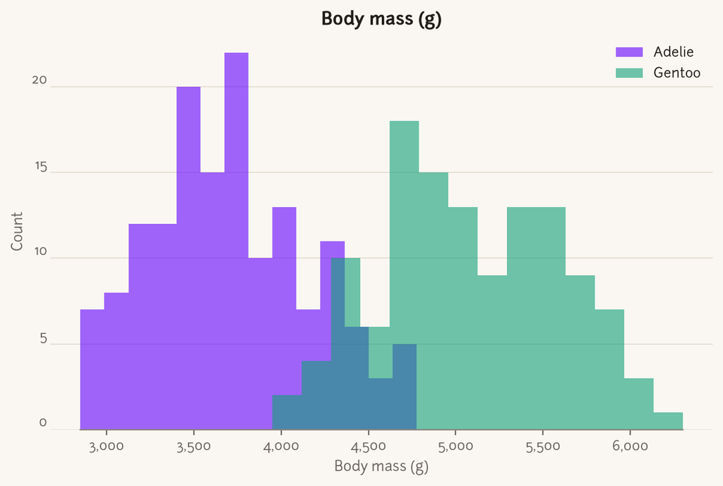

Before — a title that renames the axis, a boxed legend in the corner.

```python
adelie_mass = penguins["body_mass_g"][penguins["species"] == "Adelie"]
gentoo_mass = penguins["body_mass_g"][penguins["species"] == "Gentoo"]
pct_heavier = round(100 * (np.nanmean(gentoo_mass) / np.nanmean(adelie_mass) - 1))
adelie_color, gentoo_color = ACCENT, house_style.EMERALD

fig, ax = plt.subplots(figsize=(6.6, 4.4), constrained_layout=True)
ax.hist(adelie_mass, bins=14, color=adelie_color, alpha=0.6, label="Adelie")
ax.hist(gentoo_mass, bins=14, color=gentoo_color, alpha=0.6, label="Gentoo")
house_style.finish(ax)
house_style.units(ax, "x", "count")
ax.set_xlabel("Body mass (g)")
ax.set_title("Body mass (g)")
ax.set_ylabel("Count")
ax.legend(loc="upper right", frameon=True, fontsize=9)
```

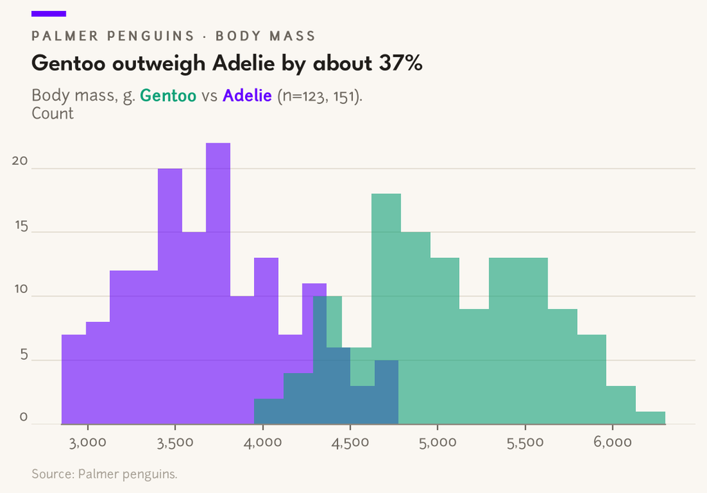

After — the finding is the title; the dek carries the key. The legend is gone.

```python
fig, ax = house_style.page(
    size=(6.6, 4.4),
    kicker="Palmer penguins · body mass",
    title=f"Gentoo outweigh Adelie by about {pct_heavier}%",
    dek=f"Body mass, g. <Gentoo> vs <Adelie> (n={len(gentoo_mass)}, {len(adelie_mass)}).",
    dek_highlights=[{"color": gentoo_color, "weight": "bold"}, {"color": adelie_color, "weight": "bold"}],
    source="Source: Palmer penguins.",
)
ax.hist(adelie_mass, bins=14, color=adelie_color, alpha=0.6)
ax.hist(gentoo_mass, bins=14, color=gentoo_color, alpha=0.6)
house_style.finish(ax)
house_style.units(ax, "x", "count")
house_style.ylabel_above(ax, "Count")
```

**ImportantExtract — M3 rules**

**Acceptance check:** cover the headline and test whether the marks support it; qualifications remain legible and series identity survives loss of hue.

1. **The title matches the evidence:** a supported takeaway, a question, or a descriptive scope. Do not imply certainty that the data lack.
2. **Colour-key the series words into the dek** with `house_style.page(dek=, dek_highlights=[...])` — a coloured word can shorten lookup. Use a legend or direct labels when colour alone or text collisions would fail.
3. **Type is hierarchy.** One clear weight/size step from title → labels → annotations; let the message sit at the top of it.

# 6 M4 — Colour: match the palette *type* to the data

Colour has three jobs, one per kind of data, and the cardinal error is using the wrong **type**:

- **Categorical** — distinct hues for *unordered* groups (`house_style.SERIES`, violet-led, CVD-validated).
- **Sequential** — one perceptually-uniform ramp for *ordered* magnitude (**viridis**, never jet/rainbow).
- **Diverging** — two hues around a *meaningful midpoint* for *signed* data (`house_style.diverging_norm`, a symmetric `TwoSlopeNorm` so neither side is exaggerated).

## 6.1 One chart, three palette types

The same five bars, coloured three ways — each palette type answers a *different question* about the values.

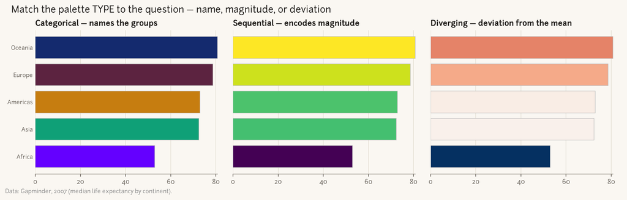

One bar chart, three palette TYPES: naming the groups, encoding magnitude, or showing deviation.

```python
is_2007 = gapminder["year"] == 2007
continent, median_life_exp = group(
    gapminder["continent"][is_2007], gapminder["lifeExp"][is_2007], np.nanmedian
)
order = np.argsort(median_life_exp)
continent, median_life_exp = continent[order], median_life_exp[order]
row = np.arange(len(median_life_exp))

fig, axes = plt.subplots(1, 3, figsize=(12, 3.6), constrained_layout=True, sharey=True)

bar_edge = dict(edgecolor="#bbbbbb", linewidth=0.6)  # keeps near-white diverging bars visible

# categorical — distinct hues just NAME the groups
axes[0].barh(row, median_life_exp, color=house_style.SERIES[: len(median_life_exp)], **bar_edge)
axes[0].set_title("Categorical — names the groups", loc="left", fontsize=11)

# sequential — a perceptually-uniform ramp ties colour to magnitude
magnitude_norm = plt.Normalize(median_life_exp.min(), median_life_exp.max())
axes[1].barh(row, median_life_exp, color=plt.cm.viridis(magnitude_norm(median_life_exp)), **bar_edge)
axes[1].set_title("Sequential — encodes magnitude", loc="left", fontsize=11)

# diverging — two hues around the mean: above / below average
deviation = median_life_exp - median_life_exp.mean()
deviation_norm = house_style.diverging_norm(deviation, 0)
axes[2].barh(row, median_life_exp, color=plt.cm.RdBu_r(deviation_norm(deviation)), **bar_edge)
axes[2].set_title("Diverging — deviation from the mean", loc="left", fontsize=11)

for ax in axes:
    ax.set_yticks(row)
    ax.set_yticklabels(continent, fontsize=8)
    house_style.finish(ax, grid="x")
fig.suptitle(
    "Match the palette TYPE to the question — name, magnitude, or deviation",
    x=0.01, ha="left", fontsize=13, weight="medium",
)
source = fig.text(
    0.0, -0.03, "Data: Gapminder, 2007 (median life expectancy by continent).", fontsize=8, color="#8a8a8a"
)
```

## 6.2 A centred diverging heatmap

Signed data — here each month’s deviation from *its own year’s* average — wants a diverging map pinned at zero, so white means “average” and the two hues are honestly symmetric.

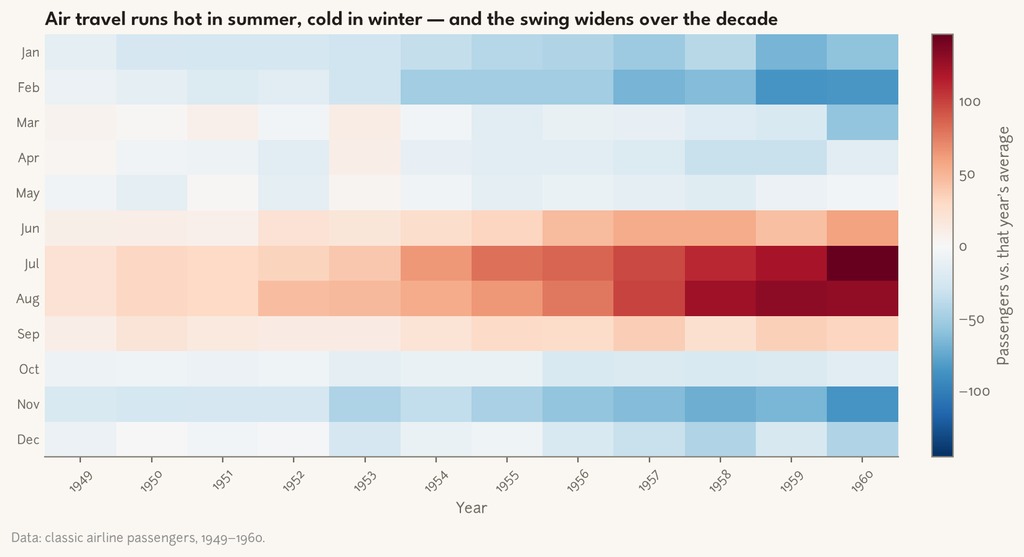

Each cell = a month’s passengers minus that year’s mean; RdBu_r on a symmetric, zero-centred norm.

```python
flights = load("flights")
_, years, passenger_matrix = pivot(
    flights["month"], flights["year"], flights["passengers"],
    rows=MONTHS, cols=np.unique(flights["year"]),  # months × years, calendar order
)
# each month minus its year's mean → signed, centred at 0
anomaly = passenger_matrix - np.nanmean(passenger_matrix, axis=0, keepdims=True)

fig, ax = plt.subplots(figsize=(9, 4.6), constrained_layout=True)
heatmap = ax.imshow(anomaly, aspect="auto", cmap="RdBu_r", norm=house_style.diverging_norm(anomaly, 0))
ax.set_yticks(range(len(MONTHS)))
ax.set_yticklabels([month_name[:3] for month_name in MONTHS], fontsize=8)
ax.set_xticks(range(len(years)))
ax.set_xticklabels(years, fontsize=8, rotation=45)
ax.set_xlabel("Year")
ax.grid(False)  # no gridlines bleeding over the heatmap cells
title(ax, "Air travel runs hot in summer, cold in winter — and the swing widens over the decade")
colorbar = fig.colorbar(heatmap, ax=ax, fraction=0.046, pad=0.04)
colorbar.set_label("Passengers vs. that year's average")
source = fig.text(0.0, -0.04, "Data: classic airline passengers, 1949–1960.", fontsize=8, color="#8a8a8a")
```

## 6.3 Before & after — jet vs. viridis

The most common colour crime: a rainbow ramp on sequential data. Same passenger matrix, two colormaps.

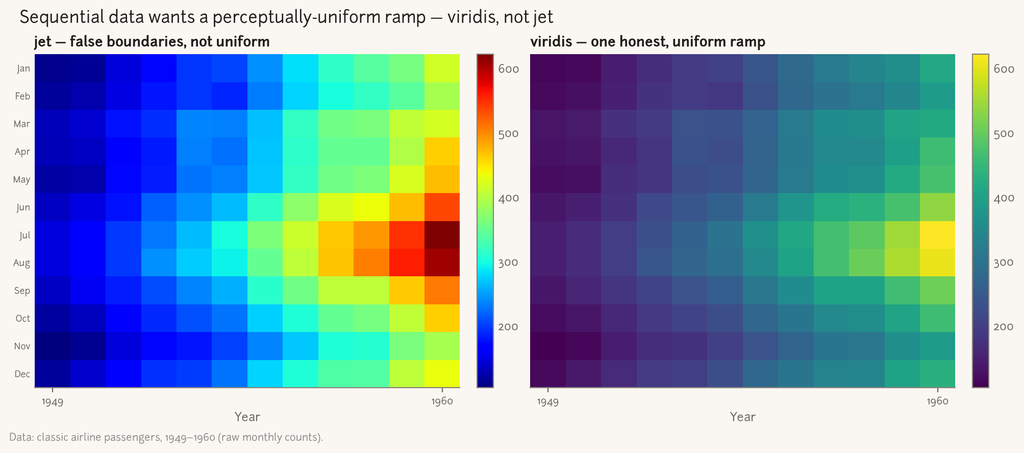

Sequential data wants a perceptually-uniform ramp: jet invents bands that aren’t in the data; viridis doesn’t.

```python
fig, (jet_ax, viridis_ax) = plt.subplots(1, 2, figsize=(11, 4.6), constrained_layout=True, sharey=True)

jet_image = jet_ax.imshow(passenger_matrix, aspect="auto", cmap="jet")
jet_ax.set_title("jet — false boundaries, not uniform", loc="left", fontsize=11)
fig.colorbar(jet_image, ax=jet_ax, fraction=0.046, pad=0.04)

viridis_image = viridis_ax.imshow(passenger_matrix, aspect="auto", cmap="viridis")
viridis_ax.set_title("viridis — one honest, uniform ramp", loc="left", fontsize=11)
fig.colorbar(viridis_image, ax=viridis_ax, fraction=0.046, pad=0.04)

for ax in (jet_ax, viridis_ax):
    ax.set_yticks(range(len(MONTHS)))
    ax.set_yticklabels([month_name[:3] for month_name in MONTHS], fontsize=7)
    ax.set_xticks([0, len(years) - 1])
    ax.set_xticklabels([years.min(), years.max()], fontsize=8)
    ax.set_xlabel("Year")
    ax.grid(False)  # no gridlines bleeding over the heatmap cells
fig.suptitle(
    "Sequential data wants a perceptually-uniform ramp — viridis, not jet",
    x=0.01, ha="left", fontsize=13, weight="medium",
)
source = fig.text(
    0.0, -0.03, "Data: classic airline passengers, 1949–1960 (raw monthly counts).", fontsize=8, color="#8a8a8a"
)
```

**ImportantExtract — M4 rules**

**Acceptance check:** palette simulation is not a chart accessibility audit. Check thin marks and text contrast; use labels, patterns or panels redundantly.

1. **Palette type follows the data:** categorical (`house_style.SERIES`) for groups, sequential (**viridis** or `house_style.SEQUENTIAL`) for magnitude, diverging (`house_style.diverging_norm`, centred, with `house_style.DIVERGING`) for signed values.
2. **Never rainbow/jet** for sequential data — it fabricates boundaries and isn’t perceptually uniform.
3. **Centre diverging maps at the meaningful midpoint**, symmetric, so neither direction is exaggerated.

# 7 M5 — Polish: remove the “default matplotlib” tell

**Principle.** Tufte’s *data-ink ratio*: every drop of ink should carry information. Most “this looks like a default” charts aren’t badly chosen — they’re just unpolished: spines flush at the corner, a dozen ticks where four would do, a grid sitting *on top* of the data, a legend box for a single series. The fix is an **ordered pass**, and `house_style.finish(ax)` is that pass in one call: a value-axis tick budget, a hairline grid behind the data, no y tick marks, and a bottom rule bounded to the data. Both panels below already wear the house theme — what changes is only the data-ink.

## 7.1 The pass on a line

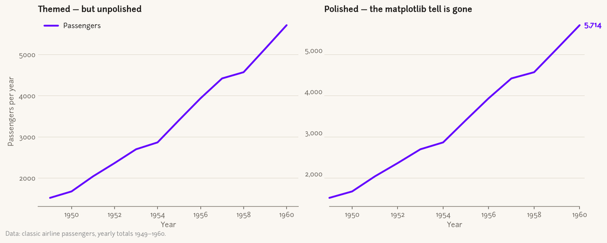

Both panels are house-themed; only the polish pass differs — a bounded axis, fewer ticks, and a direct end-label instead of a boxed legend.

```python
flights = load("flights")
year, passengers_per_year = group(flights["year"], flights["passengers"].astype(float), np.nansum)

fig, (unpolished_ax, polished_ax) = plt.subplots(1, 2, figsize=(11, 4.2), constrained_layout=True)

# BEFORE — themed, but no polish pass: flush spines, a full tick set, a boxed legend.
unpolished_ax.plot(year, passengers_per_year, color=ACCENT, lw=2.4, label="Passengers")
unpolished_ax.set_title("Themed — but unpolished", loc="left", fontsize=11)
unpolished_ax.set_xlabel("Year")
unpolished_ax.set_ylabel("Passengers per year")
unpolished_ax.legend(loc="upper left", frameon=True, fontsize=9)

# AFTER — one finish() call does the ordered pass; then label the line directly.
polished_ax.plot(year, passengers_per_year, color=ACCENT, lw=2.4)
polished_ax.margins(x=0.02)
house_style.finish(polished_ax, grid="y")
house_style.units(polished_ax, "y", "count")
polished_ax.set_title("Polished — the matplotlib tell is gone", loc="left", fontsize=11)
polished_ax.set_xlabel("Year")

final_year = year[-1]
final_passengers = passengers_per_year[-1]
end_label = polished_ax.annotate(
    f"{final_passengers:,.0f}",
    xy=(final_year, final_passengers),
    xytext=(6, 0),
    textcoords="offset points",
    va="center",
    color=ACCENT,
    fontweight="bold",
)

source = fig.text(
    0.0, -0.02, "Data: classic airline passengers, yearly totals 1949–1960.", fontsize=8, color="#8a8a8a"
)
```

## 7.2 Before & after — the same bars, polished

A vertical bar with rotated labels and the value buried on the axis is the textbook default. The polished version ranks horizontally, puts the number *on* each bar, and accents the leader — same data, far less ink spent on scaffolding.

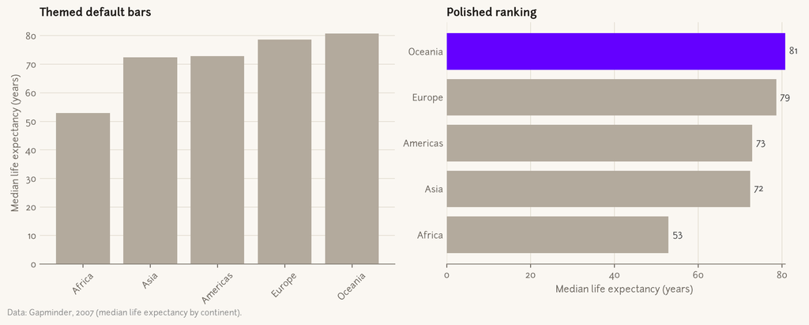

Default vertical bars vs. a polished horizontal ranking: sorted, direct value labels, one accent — both on the house theme.

```python
gapminder = load("gapminder")
is_2007 = gapminder["year"] == 2007
continent, median_life_expectancy = group(
    gapminder["continent"][is_2007], gapminder["lifeExp"][is_2007], np.nanmedian
)
rank = np.argsort(median_life_expectancy)
continent, median_life_expectancy = continent[rank], median_life_expectancy[rank]

fig, (default_ax, polished_ax) = plt.subplots(1, 2, figsize=(11, 4.2), constrained_layout=True)

# BEFORE — themed default: vertical bars, every category tick, the value left on the axis.
default_ax.bar(continent, median_life_expectancy, color=GREY)
default_ax.set_title("Themed default bars", loc="left", fontsize=11)
default_ax.set_ylabel("Median life expectancy (years)")
default_ax.tick_params(axis="x", rotation=45)

# AFTER — polished ranking: sorted, value labels on the bars, the leader in accent.
bar_position = np.arange(len(continent))
bars = polished_ax.barh(bar_position, median_life_expectancy, color=GREY)
bars[-1].set_color(ACCENT)
house_style.finish(polished_ax, grid="x")
polished_ax.set_yticks(bar_position)
polished_ax.set_yticklabels(continent)
polished_ax.set_xlabel("Median life expectancy (years)")
polished_ax.set_title("Polished ranking", loc="left", fontsize=11)
for y_position, value in zip(bar_position, median_life_expectancy):
    polished_ax.annotate(
        f"{value:.0f}",
        xy=(value, y_position),
        xytext=(4, 0),
        textcoords="offset points",
        va="center",
        fontsize=9,
        color="#444444",
    )

source = fig.text(
    0.0, -0.02, "Data: Gapminder, 2007 (median life expectancy by continent).", fontsize=8, color="#8a8a8a"
)
```

**ImportantExtract — M5 rules**

**Acceptance check:** retain grids needed for lookup, verify baselines and tick units, and reject clipped or colliding labels in exports.

1. **Run the polish pass in order:** trim + offset the spines → fewer, rounder ticks (`MaxNLocator` on the *value* axis) → grid *behind* the data (`set_axisbelow(True)`) → deliberate margins.
2. **`house_style.finish(ax, grid="y"|"x")` is the one-call lever.** Name the value axis so the categorical axis keeps its positions (bars don’t get relocated by a numeric locator).
3. **Direct labels beat axes and legends when they fit** — the value on the bar, the number at the end of the line; the eye never detours to decode a key.

# 8 M6 — House style: one theme, three registers

**Principle.** A theme is what makes a deck look like one author wrote it. The house style lives in `minerva.mplstyle` (the rcParams) and `house_style.theme()` (the one line every figure opens with). `theme` takes a **register** — the reading contract from `VISUALIZATION_GUIDE.md`: `"glance"` strips a chart down for a slide (~3 s, across a room), `"read"` is the report/README default (~30 s, arm’s length), `"study"` gives it a denser tick budget and room for an appendix (minutes, leaning in). The two figures below run the **same plotting function** — only the register argument changes.

## 8.1 Before & after — one theme, two registers

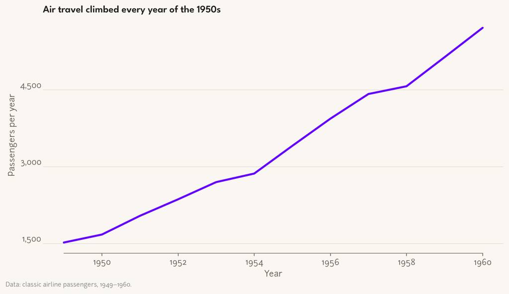

register=‘glance’ — a wide slide aspect, a larger title, a slim tick budget. The plotting body is identical to the next figure.

```python
def plot_passengers_by_year(ax):
    """The plotting body, themed by whichever register is active when it runs."""
    flights = load("flights")
    year, passengers_per_year = group(flights["year"], flights["passengers"].astype(float), np.nansum)
    ax.plot(year, passengers_per_year, color=ACCENT, lw=2.6)
    house_style.finish(ax)
    house_style.units(ax, "y", "count")
    ax.set_xlabel("Year")
    ax.set_ylabel("Passengers per year")


house_style.theme("glance")
fig, ax = plt.subplots(constrained_layout=True)
plot_passengers_by_year(ax)
title(ax, "Air travel climbed every year of the 1950s")
source = fig.text(0.0, -0.02, "Data: classic airline passengers, 1949–1960.", fontsize=8, color="#8a8a8a")
```

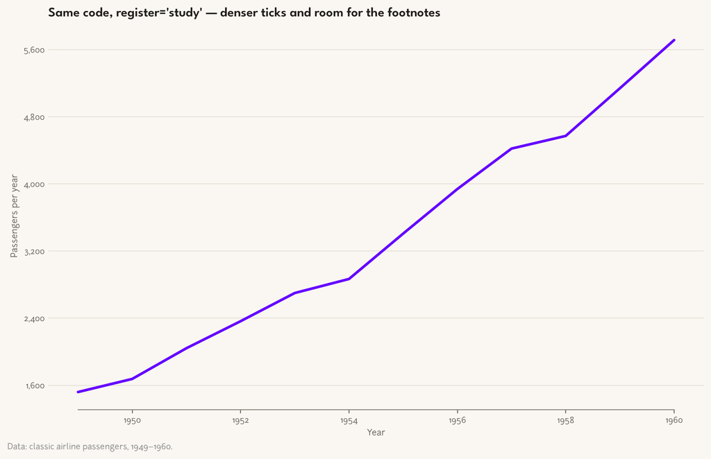

Same plot_passengers_by_year() — only register=‘study’ changed: a denser tick budget and a canvas that gives an appendix room to breathe.

```python
house_style.theme("study")
fig, ax = plt.subplots(constrained_layout=True)
plot_passengers_by_year(ax)
title(ax, "Same code, register='study' — denser ticks and room for the footnotes")
source = fig.text(0.0, -0.02, "Data: classic airline passengers, 1949–1960.", fontsize=8, color="#8a8a8a")
```

The lever is one argument; the look is wholesale. For a genuine *one-off* — a chart that needs a setting the theme doesn’t have — reach for a **context manager** (`with plt.style.context(...)` or `plt.rc_context({...})`) so the deviation is scoped and the global theme is never disturbed. `house_style.save` (next module) uses exactly this pattern to set print-only font handling at save time without touching the on-screen look.

**ImportantExtract — M6 rules**

**Acceptance check:** attention changes density, not truth. Material uncertainty and limitations remain visible in glance, read and study.

1. **`house_style.theme(register)` is the first plotting line, every time.** `"glance"` for slides and single-message charts; `"read"` for reports/READMEs; `"study"` for appendices and multi-panel figures.
2. **Define the look once, reuse it everywhere.** A shared theme — not per-chart hand-styling — is what makes a set of figures read as one consistent house. One figure, one register — re-render for a different medium.
3. **One-offs go in a context manager** (`plt.rc_context` / `plt.style.context`) so a local override never leaks into the global theme.

# 9 M7 — Composition capstone: glance vs. study, then export

**Principle.** One dataset earns **two figures**. The *glance* cut carries a single message on one accented series with the axes stripped to the point — built for a slide. The *study* cut is a multi-panel datasheet, layering a second synthetic dataset and a secondary axis — built for the appendix, with scaling caveats. Then you **export right**: vector for print and slides, a 2× PNG for the web. Synthetic DUT teaching curves throughout, two deliberate treatments, each a full `page()` — kicker, title, dek, source.

## 9.1 The glance cut — one message, one series

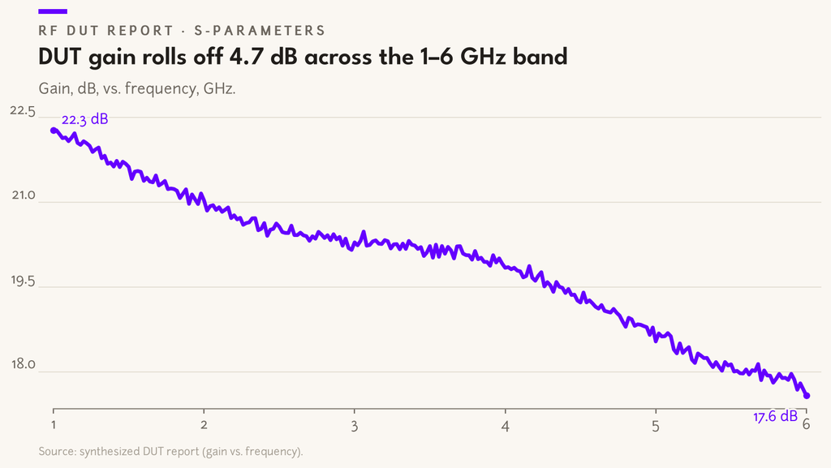

glance cut: one accented curve on a full page anatomy, the two band edges labelled — then exported as SVG + PDF + 2x PNG.

```python
house_style.theme("glance")
dut_report = load("rf_dut_report")
frequency_ghz = dut_report["freq_ghz"]
gain_db = dut_report["gain_db"]
gain_at_low_edge = gain_db[0]
gain_at_high_edge = gain_db[-1]
gain_rolloff_db = gain_at_low_edge - gain_at_high_edge

fig, ax = house_style.page(
    kicker="RF DUT report · S-parameters",
    title=f"DUT gain rolls off {gain_rolloff_db:.1f} dB across the 1–6 GHz band",
    dek="Gain, dB, vs. frequency, GHz.",
    source="Source: synthesized DUT report (gain vs. frequency).",
)
ax.plot(frequency_ghz, gain_db, color=ACCENT, lw=2.8)
house_style.finish(ax)
ax.margins(x=0.02)

# label each band edge, offset clear of the descending trace
house_style.mark(ax, frequency_ghz[0], gain_at_low_edge, f"{gain_at_low_edge:.1f} dB", dx=6, dy=8, color=ACCENT)
house_style.mark(ax, frequency_ghz[-1], gain_at_high_edge, f"{gain_at_high_edge:.1f} dB", dx=-6, dy=-16, color=ACCENT)

glance_exports = house_style.save(fig, "dut_glance")
```

## 9.2 The study cut — a multi-panel datasheet with a twin axis

The gain and efficiency scales are independent. Their crossing and apparent relative slopes have no invariant meaning: rescaling either axis would move them. Colour-keying identifies the series; it does not solve that problem. For a non-specialist audience use stacked shared-x panels instead. These curves are synthetic and their specification bands are teaching thresholds, not confidence intervals.

[figure not shown]

study cut: gain, noise figure and return loss over frequency, plus a PA compression panel whose twin axis is colour-keyed (dB to gain, % to PAE).

```python
house_style.theme("study")
dut_report = load("rf_dut_report")
frequency_ghz = dut_report["freq_ghz"]

power_amp = load("rf_pa_efficiency")
input_drive_dbm = power_amp["pin_dbm"]
pa_gain_db = power_amp["gain_db"]
pae_pct = power_amp["pae_pct"]

GAIN_COLOR = ACCENT
PAE_COLOR = house_style.SERIES[1]  # emerald — the second series' key

fig, panels = house_style.page(
    size=(11, 6.6),
    mosaic="AB\nCD",
    kicker="RF DUT report · S-parameters & PA sweep",
    title="Gain holds flat and return loss stays under spec across band",
    dek="Four measurements, one consistent sheet.",
    source="Source: synthesized DUT report + PA efficiency sweep.",
)

# A — gain over frequency (the headline parameter)
gain_ax = panels["A"]
gain_ax.plot(frequency_ghz, dut_report["gain_db"], color=GAIN_COLOR, lw=2)
house_style.panel_title(gain_ax, "Gain")
house_style.ylabel_above(gain_ax, "Gain (dB)")
house_style.finish(gain_ax)

# B — noise figure over frequency
noise_figure_ax = panels["B"]
noise_figure_ax.plot(frequency_ghz, dut_report["noise_figure_db"], color=GREY, lw=2)
house_style.panel_title(noise_figure_ax, "Noise figure")
house_style.ylabel_above(noise_figure_ax, "NF (dB)")
house_style.finish(noise_figure_ax)

# C — return loss over frequency, against the -10 dB match limit
return_loss_ax = panels["C"]
return_loss_ax.plot(frequency_ghz, dut_report["return_loss_db"], color=GREY, lw=2)
house_style.spec_band(return_loss_ax, -10, side="above", label="-10 dB match limit")
house_style.panel_title(return_loss_ax, "Return loss")
return_loss_ax.set_xlabel("Frequency (GHz)")
house_style.ylabel_above(return_loss_ax, r"$S_{11}$ (dB)")
house_style.finish(return_loss_ax)

# D — PA compression: gain (left, dB) and PAE (right, %) share a drive axis but not a scale,
#     so each y-axis is colour-keyed to its own series — identity aids, not protection against arbitrary scaling.
compression_ax = panels["D"]
compression_ax.plot(input_drive_dbm, pa_gain_db, color=GAIN_COLOR, lw=2)
house_style.panel_title(compression_ax, "PA compression & efficiency")
compression_ax.set_xlabel("Input drive (dBm)")
compression_ax.set_ylabel("Gain (dB)", color=GAIN_COLOR)
compression_ax.tick_params(axis="y", colors=GAIN_COLOR)
compression_ax.spines["left"].set_color(GAIN_COLOR)
house_style.finish(compression_ax)

pae_ax = compression_ax.twinx()
pae_ax.plot(input_drive_dbm, pae_pct, color=PAE_COLOR, lw=2)
pae_ax.set_ylabel("PAE (%)", color=PAE_COLOR)
pae_ax.tick_params(axis="y", colors=PAE_COLOR)
pae_ax.spines["right"].set_color(PAE_COLOR)
pae_ax.spines["top"].set_visible(False)

small_signal_gain_db = pa_gain_db[:5].mean()
p1db_index = int(np.argmin(np.abs(pa_gain_db - (small_signal_gain_db - 1.0))))
house_style.mark(
    compression_ax, input_drive_dbm[p1db_index], pa_gain_db[p1db_index], "P1dB",
    dx=-14, dy=18, color=GAIN_COLOR,
)

study_exports = house_style.save(fig, "dut_study")
```

Each `save` call wrote three files to `outputs/`: an **SVG** and a **PDF** (vector, for print and slides — the PDF embeds a font subset, the SVG draws text as paths so it renders anywhere) and a **PNG** at 2× dpi for the web. The registers (`glance` / `study`) and the export are deliberately separate concerns: `save` sets its print-only font handling inside an `rc_context`, so saving never disturbs the on-screen theme, and — unlike `bbox_inches="tight"` — never shaves the page’s deliberate margins.

**ImportantExtract — M7 rules**

**Acceptance check:** synthetic status travels with the chart. The twin-axis panel is a domain convention, not a scale-invariant comparison; crossings and relative slopes are not evidence. Prefer shared-x panels for general readers.

1. **One dataset, two figures.** A glance cut (one message, one accent, axes stripped) for the slide; a study cut (multi-panel datasheet, a layered second dataset, annotations) for the appendix. Choose by register.
2. **Prefer shared-x panels.** If domain readers need twin axes, label both units and identify series redundantly; explain that crossings and relative slopes depend on arbitrary scales.
3. **Export every figure with `house_style.save`:** SVG + PDF (vector, fonts handled) for print and slides, PNG at 2× dpi for web — never `bbox_inches="tight"` on a `page()` figure.

# Decision lab — uncertainty survives the register

A request says: “Show that the redesign is faster.” Do not accept the conclusion as an input. Here the reader is a colleague deciding whether a **synthetic paired trial** warrants further testing. The task is estimating a change, not celebrating a winning average. Each row below represents the same fictional participant under two conditions. Improvement is old minus new completion time.

We generate 24 independent fictional participants with a fixed seed, then bootstrap the **paired differences**, not the two conditions separately. The interval is a 95% percentile bootstrap interval for the mean difference under this teaching model (10,000 resamples). It does not account for order effects, selection bias or real deployment conditions. The generated mean is deliberately near zero; this is an uncertainty demonstration, not evidence about an actual redesign.

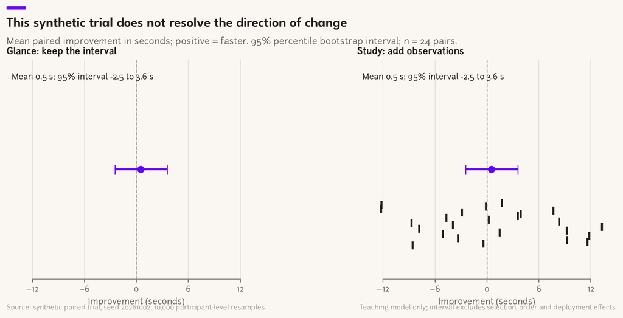

Synthetic paired trial: the same mean improvement and 95% bootstrap interval in glance and study. The interval spans zero; the trial does not resolve the direction of the mean change.

```python
trial_rng = np.random.default_rng(20261002)
old_seconds = trial_rng.normal(60, 8, 24)
raw_improvement = trial_rng.normal(0, 6, 24)
improvement_seconds = raw_improvement - raw_improvement.mean() + 0.5
new_seconds = old_seconds - improvement_seconds
paired_difference = old_seconds - new_seconds
bootstrap_means = trial_rng.choice(paired_difference, size=(10000, 24), replace=True).mean(axis=1)
interval_low, interval_high = np.quantile(bootstrap_means, [0.025, 0.975])
mean_improvement = paired_difference.mean()
assert interval_low < 0 < interval_high
assert np.isclose(mean_improvement, 0.5)

house_style.theme("read")
fig, uncertainty_axes = house_style.page(
    size=(10.2, 5.0), mosaic="AB",
    title="This synthetic trial does not resolve the direction of change",
    dek="Mean paired improvement in seconds; positive = faster. 95% percentile bootstrap interval; n = 24 pairs.",
    source="Source: synthetic paired trial, seed 20261002; 10,000 participant-level resamples.",
    note="Teaching model only; interval excludes selection, order and deployment effects.",
)
for panel_key, register_label in [("A", "Glance: keep the interval"), ("B", "Study: add observations")]:
    interval_ax = uncertainty_axes[panel_key]
    interval_ax.axvline(0, color=house_style.CONTEXT, linestyle="--", linewidth=1)
    interval_ax.errorbar(
        mean_improvement, 0,
        xerr=[[mean_improvement - interval_low], [interval_high - mean_improvement]],
        fmt="o", color=ACCENT, capsize=5, markersize=7,
    )
    interval_ax.text(
        0.02, 0.91, f"Mean {mean_improvement:.1f} s; 95% interval {interval_low:.1f} to {interval_high:.1f} s",
        transform=interval_ax.transAxes, fontsize=9,
    )
    interval_ax.set(xlim=(-15, 15), ylim=(-0.65, 0.65), yticks=[], xlabel="Improvement (seconds)")
    house_style.panel_title(interval_ax, register_label)
    house_style.finish(interval_ax, grid="x")
uncertainty_axes["B"].scatter(
    paired_difference, np.linspace(-0.45, -0.2, len(paired_difference)),
    color=house_style.INK, marker="|", s=80,
)
plt.show()
```

Both panels deliberately share one figure register and scale for comparison; the panel labels describe information budgets, not separate `theme()` calls. The interval remains in the glance budget because removing it would change the conclusion. In production, render each destination separately and inspect its final dimensions. A zero-crossing interval is not proof of no effect or practical equivalence.

The same evidence in text (a usable alternative to decoding the image):

```python
print("| Quantity | Value |\n|---|---:|")
print(f"| Synthetic paired participants | {len(paired_difference)} |")
print(f"| Mean improvement, seconds | {mean_improvement:.2f} |")
print(f"| 95% bootstrap interval, seconds | {interval_low:.2f} to {interval_high:.2f} |")
print("\nPositive means faster. These simulated observations cannot establish a real product effect.")
```

| Quantity | Value |
| --- | --- |
| Synthetic paired participants | 24 |
| Mean improvement, seconds | 0.50 |
| 95% bootstrap interval, seconds | -2.46 to 3.58 |

Positive means faster. These simulated observations cannot establish a real product effect.

**Release checks:** preserve pairing and sample size; recompute the interval from the recorded seed; keep the zero reference and units; label the method and synthetic status; include the visible caveat and text alternative; check output size and contrast. Do not use overlap between two unrelated error bars as a substitute for estimating the paired difference.

**Reusable rule:** when uncertainty can reverse the decision, spend the attention budget on it before spending that budget on decoration. Simplify the question or split the view rather than hide the limit.

# 10 M8 — Tables inside figures: the evidence ledger

This chapter proposes an **evidence ledger**: a figure in which each row binds an identity, a visual comparison and an exact numerical account. This is our name for a reusable composition, not a claim that forest plots or integrated tables are new inventions. The novel lesson is the *contract*: the picture, the table and the accessible alternative must come from the same records, share the same ordering, and answer the same question.

A graph is good at “which, how much, and how variable?” A table is good at “exactly what number, for whom, out of how many?” Put them together only when both questions matter. A table **inside the figure** need not sit **over the data**. Reserve a lane in the canvas, not an opaque box over points.

## 10.1 An anatomy that earns its space

Think in four layers:

1. **Identity:** participant, trial or subgroup, left-aligned in a stable row order.
2. **Shape:** positions, paired segments or interval marks on a common quantitative scale.
3. **Account:** exact estimates, interval endpoints and denominators in aligned numeric columns.
4. **Terms:** units, the comparison direction, interval method, source and inferential limits.

The first three share row coordinates. The fourth belongs to a caption/source band, not a microscopic footnote inside the plot. The column headers carry units once. Align numbers right, use consistent precision within a column, and reserve a dash for “not applicable,” never for zero or missing data. Avoid vertical rules; a header rule and a line between conceptual blocks are usually enough. If long labels force smaller type, widen the identity lane, split the figure, or move low-priority columns out.

These are design proposals to test at delivery size, not universal laws. A dense regulatory table can need stronger rules; a single annotated value may not need a table at all.

| Placement | Use when | Avoid when |
| --- | --- | --- |
| Shared-row sidecar | The reader compares an estimate and its exact value repeatedly | Long descriptions swamp the plot lane |
| Footer strip inside the figure | Only one or two summary rows support a large plot | Readers must trace ten rows across a gap |
| Small inset table | A genuinely empty region survives changes to limits and data | It masks points, uncertainty, or an important tail |
| Separate accessible table | Exact lookup, copying, mobile reading or assistive technology is primary | Never omit this merely because numbers also appear in the image |

### Why not just call `ax.table()`?

That is a reasonable starting point for a small rectangular table. Turn off automatic font shrinking, set cell widths deliberately, and remove unnecessary edges. Matplotlib’s documentation notes that line breaks are not automatically accommodated by its table implementation. For the irregular rows below, separate axes and text artists give us direct control over alignment and spacing ([Matplotlib table API](https://matplotlib.org/stable/api/table_api.html)).

```python
# The actual helper in evidence_tables.py uses this coordinate contract:
fig = plt.figure(figsize=(12, 6))
grid = fig.add_gridspec(1, 3, width_ratios=[2.2, 4.2, 3.6])
labels = fig.add_subplot(grid[0, 0])
plot = fig.add_subplot(grid[0, 1], sharey=labels)
numbers = fig.add_subplot(grid[0, 2], sharey=labels)
for ax in (labels, plot, numbers):
    ax.set_ylim(n_rows - .4, -1.6)  # rows 0..n-1; header at y=-1
numbers.text(.98, row, exact_value, ha="right",
             transform=numbers.get_yaxis_transform())
# x is a fraction of the table lane; y is the SAME row coordinate as the marks.
```

The short scaffold is explanatory; the executable implementation is in `evidence_tables.py`. It separates calculations from composition so labels cannot silently drift away from plotted values.

## 10.2 Case 1 — Student’s sleep data: one dataset, three audiences

The historical `sleep` dataset in R records two measurements on each of ten people, not two independent groups. Values are extra sleep hours relative to control. The paired structure is explicit in the [R dataset documentation](https://www.stat.ethz.ch/R-manual/R-devel/library/datasets/html/sleep.html); our numeric transcription follows the [R source](https://raw.githubusercontent.com/wch/r-source/trunk/src/library/datasets/data/sleep.R). This is a statistical teaching example, not current evidence for choosing a medicine.

### Before — a table that repeats the wrong answer

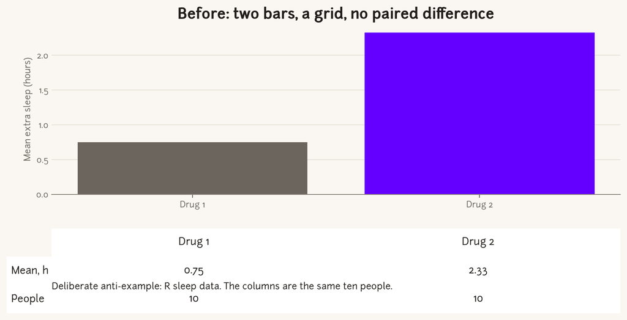

Figure 2: The grid adds exact means, but the composition still fails to show the paired difference or its uncertainty.

```python
import evidence_tables as et
et.sleep_before()
plt.show()
```

Removing gridlines would make this quieter, not more informative. The important repair is to change what the table carries: the **comparison and its uncertainty**, not just numbers already encoded by bars.

### Glance — the decision card

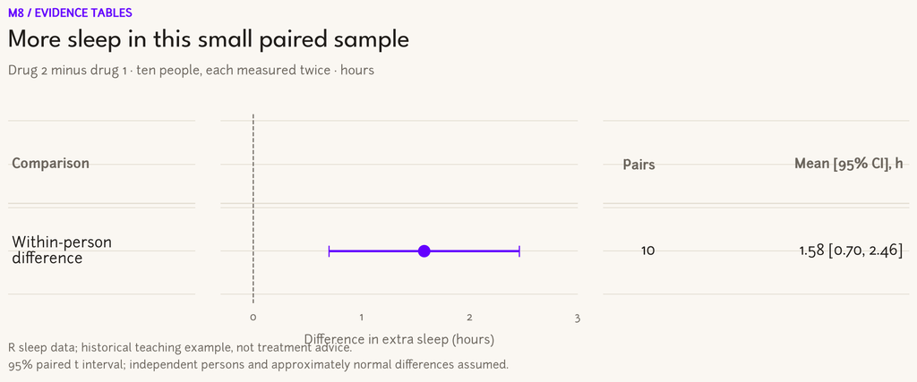

Figure 3: A one-row table inside a figure: the interval provides shape; the exact estimate and paired sample size provide an account.

```python
et.sleep_glance()
plt.show()
```

Our design choice for a decision-maker: one contrast, one interval, one denominator. No p-value column, no repeated arm summaries, and no deletion of uncertainty to make the card look decisive. If the audience has a meaningful threshold, place it on the scale and explain its origin; do not invent one for emphasis.

### Read — the comparison needs a row of its own

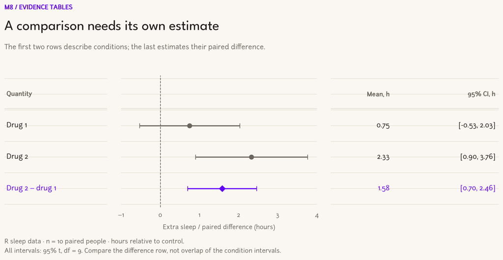

Figure 4: Condition summaries and the paired contrast are distinct quantities. The accent belongs to the comparison, not to a favored treatment.

```python
et.sleep_read()
plt.show()
```

For an analyst reading a report, keep the arm context but give the estimand—what we are actually estimating—its own row. The first two intervals concern condition means; the last concerns within-person differences. Do not substitute the former for the latter. Here the paired interval is computed as $\bar d \pm t_{9,0.975}s_d/\sqrt{10}$, with a fixed critical value of 2.262157. It assumes independent people and approximately normal differences; pairing alone does not establish causal identification.

### Study — the audit view

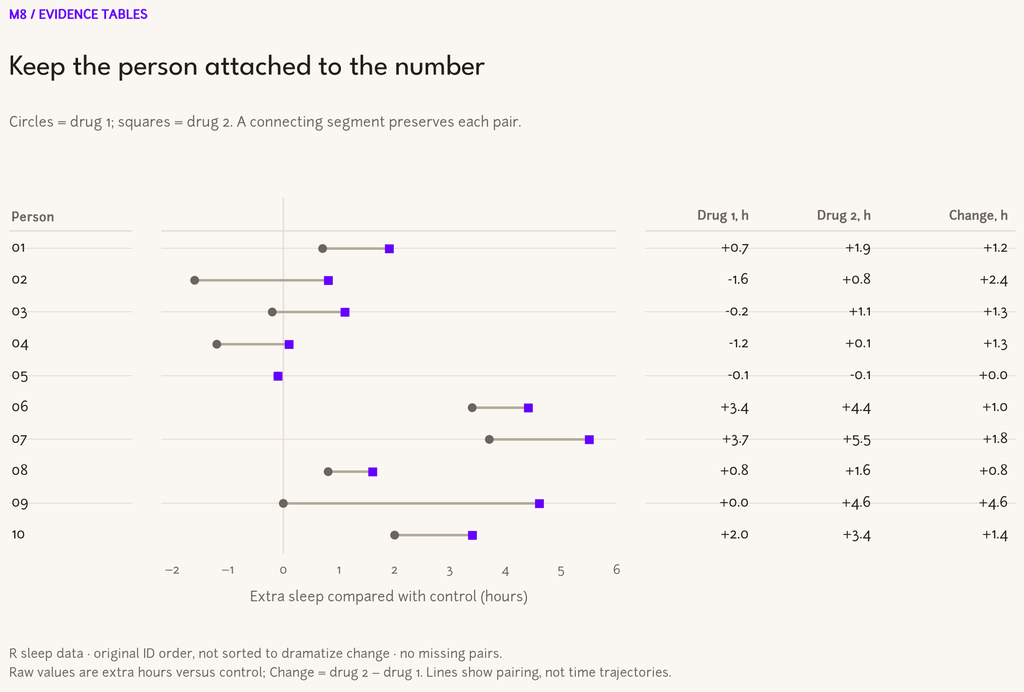

Figure 5: The table is now part of the graphic: a reader can inspect each pair and retrieve its exact values without matching a detached spreadsheet.

```python
et.sleep_study()
plt.show()
```

A reviewer gets identities and raw pairs, not a shrunken version of the decision card. Keep the original row order unless a different ordering serves an explicit question. Explain that the connecting lines encode pairing, not a continuous time trajectory. A tied pair still needs both values in the table.

**NoteAudience changes the lookup burden, not the truth**

| Register | Reader’s task | Inside-figure table | What must remain |
| --- | --- | --- | --- |
| Glance | Understand the main comparison | Pairs, effect, interval | Direction, units, uncertainty, small-sample caveat |
| Read | Relate conditions to the comparison | Condition means plus a contrast row | The distinction between summaries and estimand |
| Study | Audit records and assumptions | Raw paired values and differences | IDs/order, pairing, source and method |

Do not squeeze the study figure into a phone-width column. Offer the simpler view plus the following real text table, or a sufficiently large downloadable figure. Typography is a delivery constraint.

### Accessible values — generated from the same arrays

```python
et.markdown_table(["Person", "Drug 1 extra sleep (h)", "Drug 2 extra sleep (h)", "Paired difference (h)"],
    [(i+1, f"{a:.1f}", f"{b:.1f}", f"{b-a:.1f}")
     for i, (a,b) in enumerate(zip(et.SLEEP_1, et.SLEEP_2))])
et.markdown_table(["Quantity", "Mean (h)", "95% t interval (h)", "People"],
    [(label, f"{m:.2f}", f"{lo:.2f} to {hi:.2f}", 10)
     for label, (m,lo,hi) in zip(["Drug 1", "Drug 2", "Drug 2 minus drug 1"],
       [et.mean_ci10(v) for v in (et.SLEEP_1, et.SLEEP_2, et.SLEEP_2-et.SLEEP_1)])])
```

| Person | Drug 1 extra sleep (h) | Drug 2 extra sleep (h) | Paired difference (h) |
| --- | --- | --- | --- |
| 1 | 0.7 | 1.9 | 1.2 |
| 2 | -1.6 | 0.8 | 2.4 |
| 3 | -0.2 | 1.1 | 1.3 |
| 4 | -1.2 | 0.1 | 1.3 |
| 5 | -0.1 | -0.1 | 0.0 |
| 6 | 3.4 | 4.4 | 1.0 |
| 7 | 3.7 | 5.5 | 1.8 |
| 8 | 0.8 | 1.6 | 0.8 |
| 9 | 0.0 | 4.6 | 4.6 |
| 10 | 2.0 | 3.4 | 1.4 |

| Quantity | Mean (h) | 95% t interval (h) | People |
| --- | --- | --- | --- |
| Drug 1 | 0.75 | -0.53 to 2.03 | 10 |
| Drug 2 | 2.33 | 0.90 to 3.76 | 10 |
| Drug 2 minus drug 1 | 1.58 | 0.70 to 2.46 | 10 |